# A Robust Machine Learning Framework for Outcome-wide Exposome Data Analysis

A Comprehensive msRRR Hands-On Tutorial

Augusto Anguita-Ruiz | Methodology & Implementation

julio 01, 2026

# 1 1. INTRODUCTION: The High-Dimensional Challenge

## 1.1 1.1 The Curse of Dimensionality: From Univariate to Outcome-Wide Analysis

The concept of the “exposome” encompasses all environmental exposures to which an individual is subjected from conception onward (Wild 2005). An increasing number of studies have evidenced the fundamental role of the early-life exposome in the development of the most common non-communicable diseases, pointing to the prenatal and early childhood periods as critical windows of opportunity for disease prevention (Agier et al. 2019; Maitre et al. 2021; Vrijheid et al. 2020).

Traditionally, exposome research has focused on studying different health outcomes separately, under what is known as the single-outcome approach (Barrera-Gómez et al. 2017; Vrijheid et al. 2020). Although this analysis is valid, it often fails to provide a comprehensive vision, especially when exposures are presumed to have multiple, interconnected effects on health. To overcome this, advanced methods for *outcome-wide* analysis have been developed, where the effect of an environmental exposure on multiple health outcomes is investigated simultaneously (VanderWeele 2017; VanderWeele et al. 2020).

**The Power of the Outcome-Wide Exposome Approach**

Outcome-wide studies offer critical benefits in exposome research. Environmental exposures rarely affect a single biological system; instead, they influence multiple health outcomes that usually manifest in populations as complex comorbidities (e.g., cardiometabolic alterations co-occurring with respiratory problems and neurodevelopmental delays).

Methodologically, an outcome-wide analysis directly models the correlations among these multiple exposures and diverse outcomes. This allows the model to “borrow information” across different exposure-outcome pairs. Consequently, it significantly increases the statistical power to detect subtle, yet highly relevant, signals that would not be strong enough to reach significance in a traditional, isolated single-outcome analysis (Kundu et al. 2021). Furthermore, this holistic perspective can uncover ambiguous or pleiotropic risk factors—exposures that might be beneficial for one biological system but harmful to another—while inherently preventing the selective reporting of results and avoiding the massive statistical penalties associated with multiple testing. From a public health perspective, identifying these “master” environmental drivers that simultaneously impact multiple disease pathways is invaluable for designing high-impact preventive interventions.

**The Analytical Challenge and the msRRR Solution**

Despite its theoretical advantages, outcome-wide exposome research poses severe statistical challenges: the massive increase in dimensionality (the classic $P \gg N$ problem), the extreme collinearity among environmental variables, the exponential risk of false positives, and the need to integrate mixed-type responses. While most previous studies have relied on classical multivariate regressions that barely improve efficiency, the most advanced solutions stem from the omics fields, designed to identify “master regulators”.

To robustly address these challenges, this pipeline implements the **msRRR (Mixed-Response Sparse Reduced-Rank Regression)** framework. The model minimizes:
$$-\log L(Y,
X, Z) + \lambda ||U||_{2,1} \quad \text{s.t.} \quad V^T V =
I_r$$

Where: - **-log L**: Likelihood fit (Gaussian for continuous, Binomial for binary) - **λ||U||₂,₁**: Group-Lasso penalty shrinking weak exposures - **Rank constraint**: Data flows through r latent factors (B = UV^T)

This statistical engine is specifically tailored for the exposome’s complexities:

1. **Simultaneous Mixed Responses:** It allows integrating outcomes of different statistical natures into a single mathematical architecture (e.g., continuous variables like BMI z-score alongside binary variables like Asthma diagnosis).
2. **Dimensionality Reduction (Rank $r$):** It assumes that exposures affect health outcomes through latent factors or “shared biological pathways,” leveraging the comorbidity structure to radically simplify the model.
3. **Strict Sparsity (Group-Lasso):** It applies a mathematical penalty ($\lambda$) that forces the coefficients of irrelevant exposures to exactly zero, acting as a rigorous noise filter that neutralizes the false-positive explosion typical of high-dimensional environments.
4. **Validation Architecture**: Strict train/test separation prevents data leakage
5. **Stability Selection**: 500-iteration balanced bootstrap to distinguish true drivers from noise

# 2 2. SETUP: Environment Configuration & Library Loading

## 2.1 2.1 Theoretical Motivation for Setup

Before analyzing data, we must ensure: - **Reproducibility**: Clean environment, fixed packages - **Computational Efficiency**: Parallel processing for 500 bootstraps - **Function Access**: Custom msRRR and bootstrapping functions loaded

This prevents silent errors and allows the pipeline to scale to large datasets.

```r
# ------------------------------------------------------------------------------
# BLOCK 1: SET UP & LIBRARIES
# ------------------------------------------------------------------------------

# Clean environment
rm(list = ls())

# Define all required packages
required_packages <- c(
  "tidyverse", "rrpack", "foreach", "doParallel", "pheatmap", "glmnet",
  "fastDummies", "gridExtra", "corrplot", "caret", "ggrepel", "reshape2",
  "RColorBrewer", "grid", "doSNOW", "matrixStats", "RMTL"
  )

# Install missing packages
new_packages <- required_packages[!(required_packages %in% installed.packages()[,"Package"])]
if(length(new_packages)) install.packages(new_packages)

# Load libraries
suppressPackageStartupMessages({
  library(tidyverse)
  library(rrpack)
  library(foreach)
  library(doParallel)
  library(pheatmap)
  library(glmnet)
  library(fastDummies)
  library(gridExtra)
  library(corrplot)
  library(caret)
  library(ggrepel)
  library(reshape2)
  library(RColorBrewer)
  library(grid)
})

# SOURCE EXTERNAL FUNCTIONS
# Ensure these files are in a 'functions' subfolder
if(file.exists("functions/msrrr_v3.R")) {
  source("functions/msrrr_v3.R")
  source("functions/bootstrapping_functions_aug_25_03_24.r")
  message(">>> Setup Complete. Libraries and Functions loaded.")
} else {
  stop("ERROR: Functions not found. Please check your 'functions' folder.")
}
```

**Key Packages:** - `rrpack`: Implements reduced-rank regression core - `doParallel`: Parallelizes bootstrap iterations - `pheatmap`: Professional heatmap visualization - `tidyverse`: Data manipulation and ggplot2 graphics

# 3 3. DATA LOADING: Structure & Hierarchy

## 3.1 3.1 Why Data Structure Matters

Real epidemiological data requires: 1. **Multiple formats**: European CSV format (semicolons, comma decimals) 2. **Multiple matrices**: - **X** (Exposures): Hundreds of environmental factors - **Y** (Outcomes): Mixed continuous & binary health measures - **Z** (Covariates): Confounders (sex, age, cohort, education, maternal BMI,…) 3. **Codebook alignment**: Variable metadata for family grouping

```r
# ------------------------------------------------------------------------------
# BLOCK 2: LOAD DATA
# ------------------------------------------------------------------------------

# Helper to read European CSVs (semicolon separated, comma decimals)
read_euro_csv <- function(filename) {
  read_delim(filename, delim = ";",
             locale = locale(decimal_mark = ","),
             show_col_types = FALSE)
}

message(">>> Loading data files...")
covs_raw <- read_euro_csv("data/covariates.csv")
exp_raw  <- read_euro_csv("data/exposome.csv")
# Loading the version with NAs as requested (Standard CSV read)
phen_raw <- read.csv("data/phenotype_NA.csv", row.names = 1, na.strings = "NA")
```

# 4 4. VARIABLE SELECTION & PROCESSING: Strategic Filtering

## 4.1 4.1 The Variable Selection Rationale

For this practical tutorial, we will use data from the **HELIX exposome study**. The HELIX study is a collaborative project between six longitudinal, population-based birth cohort studies from six European countries (France, Greece, Lithuania, Norway, Spain and the UK).

**Note:** The data provided in this introductory course were semi-simulated from the real data of the HELIX sub-cohort. For more details on the HELIX project and the origin of the data collected we recommend consulting the following publication: https://bmjopen.bmj.com/content/8/9/e021311 and website: https://www.projecthelix.eu/es.

- The **exposome data (n = 1301)** that we will use are contained in separated csv files:
1. `phenotype` (outcomes)
2. `exposome` (exposome)
3. `covariates` (covariates)

The `exposome` database contains more than **200 exposures**.The description of each variable (name, structure, variable type, transformation, …) is detailed in the [codebook]. **Here, we will use the codebook to pre-select exposures and outcomes for this tutorial**.

```r
# ------------------------------------------------------------------------------
# BLOCK 3: VARIABLE SELECTION & PROCESSING
# ------------------------------------------------------------------------------
message(">>> [Block 3] Starting Variable Selection with fastDummies...")

# 3.1 Load Codebook
codebook <- read_euro_csv("data/codebook.csv")

# A. Target Families (Numeric variables)
target_families <- c(
  "Air Pollution", "Built environment", "Indoor air", "Lifestyle",
  "Metals", "Meteorological", "Natural Spaces", "Organochlorines",
  "Per- and polyfluoroalkyl substances (PFAS)", "Social and economic capital",
  "Tobacco Smoke", "Traffic", "Water DBPs"
)

# B. Forced Factors (Variables to convert to Dummies)
forced_factors <- c(
  "e3_alcpreg_yn_None", "h_pamod_t3_None", "h_pavig_t3_None",
  "FAS_cat_None", "hs_globalexp2_None"
)

# 3.2 Filter Variables from Codebook
vars_info <- codebook %>%
  filter(
    (family %in% target_families & var_type == "numeric") |
      (variable_name %in% forced_factors)
  )

# 3.3 Split Variables by Period
vars_preg_names  <- vars_info %>% filter(period == "Pregnancy") %>% pull(variable_name)
vars_child_names <- vars_info %>% filter(period == "Postnatal") %>% pull(variable_name)

# Intersect with available data (Safety check)
vars_preg_names  <- intersect(vars_preg_names, colnames(exp_raw))
vars_child_names <- intersect(vars_child_names, colnames(exp_raw))


# 3.4 Process Exposome Matrices (X)
process_exposome_matrix <- function(df_raw, var_names, factors_list) {

  # 1. Select specific variables
  df_subset <- df_raw %>% select(all_of(var_names))

  # 2. Identify which 'forced_factors' are present
  present_factors <- intersect(factors_list, colnames(df_subset))

  if(length(present_factors) > 0) {
    # Ensure they are factors
    df_subset <- df_subset %>%
      mutate(across(all_of(present_factors), as.factor))

    # 3. Apply dummy_cols (remove first dummy to avoid collinearity)
    df_subset <- dummy_cols(df_subset,
                            select_columns = present_factors,
                            remove_first_dummy = TRUE,
                            remove_selected_columns = TRUE)
  }

  # 4. Convert to Matrix
  mat <- as.matrix(df_subset)
  return(mat)
}

message("    Processing Pregnancy Matrix...")
X_preg <- process_exposome_matrix(exp_raw, vars_preg_names, forced_factors)

message("    Processing Childhood Matrix...")
X_child <- process_exposome_matrix(exp_raw, vars_child_names, forced_factors)

message(paste("    -> X_preg dimensions:", nrow(X_preg), "x", ncol(X_preg)))
message(paste("    -> X_child dimensions:", nrow(X_child), "x", ncol(X_child)))


# 3.5 Process Covariates (Z)
covs_list <- c("h_mbmi_None", "e3_gac_None", "e3_sex_None",
               "h_age_None", "h_cohort", "h_edumc_None")

Z_df <- covs_raw %>%
  select(all_of(covs_list)) %>%
  mutate(
    e3_sex_None = case_when(
      e3_sex_None == "female" ~ 0,
      e3_sex_None == "male" ~ 1,
      TRUE ~ NA_real_
    ),
    h_cohort = as.factor(h_cohort),
    h_edumc_None = as.factor(h_edumc_None)
  )

Z_df_dummies <- dummy_cols(Z_df,
                           select_columns = c("h_cohort", "h_edumc_None"),
                           remove_first_dummy = TRUE,
                           remove_selected_columns = TRUE)

Z <- as.matrix(Z_df_dummies)
message(paste("    -> Covariates dimensions:", nrow(Z), "vars.", ncol(Z)))

# 3.6 Process Outcomes (Y)
# UPDATED: Added "hs_bmi_c_cat" to the list
outcomes_list <- c(
  "e3_bw", "hs_asthma", "hs_zbmi_who",
  "hs_correct_raven", "hs_Gen_Tot", "hs_bmi_c_cat"
)

Y_df <- phen_raw %>%
  select(all_of(outcomes_list)) %>%
  # Force numeric on all columns (this handles hs_bmi_c_cat categorical -> numeric)
  mutate(across(everything(), as.numeric))

Y <- as.matrix(Y_df)
message(paste("    -> Outcomes (Y) Ready:", ncol(Y), "vars."))
```

# 5 5. QUALITY CONTROL: Data Integrity Verification

## 5.1 5.1 Evaluation of missingness in the outcome space

Missing data can introduce systematic bias. Despite our msRRR methods can handle missing values in outcomes, before analysis, we will always: 1. Count NAs per variable 2. Report complete case percentages 3. Flag variables with excessive missingness

```r
# ------------------------------------------------------------------------------
# BLOCK 3.7: QUALITY CONTROL - NA COUNT PER VARIABLE
# ------------------------------------------------------------------------------
message(">>> [Block 3.7] Running NA Quality Checks (Counts)...")

# Function to report NAs per variable
report_nas <- function(data_obj, name) {
  if(is.matrix(data_obj)) data_obj <- as.data.frame(data_obj)

  message(paste0("\n--- Checking Dataset: ", name, " ---"))

  na_counts <- colSums(is.na(data_obj))
  vars_with_na <- na_counts[na_counts > 0]

  if(length(vars_with_na) > 0) {
    message(paste("    Found", length(vars_with_na), "variables with missing values."))
    print(vars_with_na)
  } else {
    message("    OK: No missing values found (Complete).")
  }

  n_complete <- sum(complete.cases(data_obj))
  pct_complete <- round((n_complete / nrow(data_obj)) * 100, 1)
  message(paste0("    Complete Cases (Rows): ", n_complete, "/", nrow(data_obj),
                 " (", pct_complete, "%)"))
}

# Run Checks
report_nas(X_preg,  "Exposome Pregnancy (X_preg)")
report_nas(X_child, "Exposome Childhood (X_child)")
report_nas(Z,       "Covariates (Z)")
report_nas(Y,       "Phenotypes/Outcomes (Y)")
```

```
           e3_bw        hs_asthma hs_correct_raven       hs_Gen_Tot
              17                7               10                8
```

Also, we will create plots that summarize **missingness patterns**:

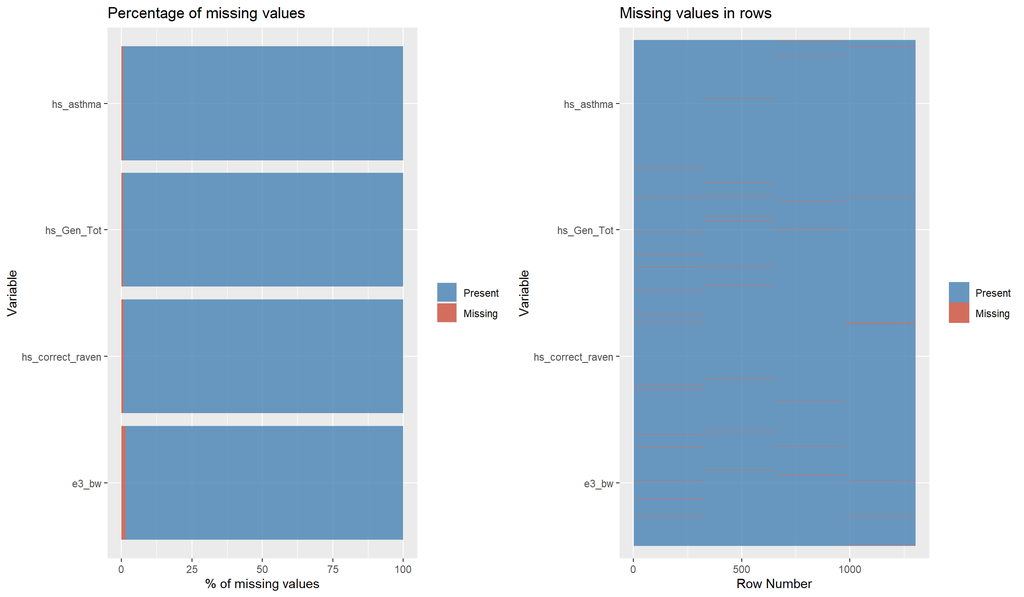

```r
# ------------------------------------------------------------------------------
# BLOCK 3.8: MISSING VALUES VISUALIZATION (Phenotypes)
# ------------------------------------------------------------------------------
message("\n>>> [Block 3.8] Generating Missing Values Plots...")

# Use Y_df (dataframe) for plotting
df_ <- Y_df

# 1. Prepare Data for Percentage Plot
missing.values <- df_ %>%
  gather(key = "key", value = "val") %>%
  mutate(isna = is.na(val)) %>%
  group_by(key) %>%
  mutate(total = n()) %>%
  group_by(key, total, isna) %>%
  summarise(num.isna = n(), .groups = 'drop') %>%
  mutate(pct = num.isna / total * 100)

levels <- (missing.values %>% filter(isna == TRUE) %>% arrange(desc(pct)))$key
if(length(levels) == 0) levels <- unique(missing.values$key)

# 2. Percentage Bar Plot
percentage.plot <- missing.values %>%
  ggplot() +
  geom_bar(aes(x = reorder(key, desc(pct)), y = pct, fill=isna),
           stat = 'identity', alpha=0.8) +
  scale_x_discrete(limits = levels) +
  scale_fill_manual(name = "", values = c('steelblue', 'tomato3'),
                    labels = c("Present", "Missing")) +
  coord_flip() +
  labs(title = "Percentage of missing values", x = 'Variable', y = "% of missing values")

# 3. Row Missingness Plot
row.plot <- df_ %>%
  mutate(id = row_number()) %>%
  gather(-id, key = "key", value = "val") %>%
  mutate(isna = is.na(val)) %>%
  ggplot(aes(key, id, fill = isna)) +
  geom_raster(alpha=0.8) +
  scale_fill_manual(name = "", values = c('steelblue', 'tomato3'),
                    labels = c("Present", "Missing")) +
  scale_x_discrete(limits = levels) +
  labs(x = "Variable", y = "Row Number", title = "Missing values in rows") +
  coord_flip()

# 4. Display Plots
grid.arrange(percentage.plot, row.plot, ncol = 2)
```

```r
# 5. Complete Cases Analysis Report
cc_matrix <- na.omit(df_)
message(paste0("\n>>> COMPLETE CASES ANALYSIS for PHENOTYPES:"))
message(paste0("    Original Dimensions: ", paste(dim(df_), collapse = " x ")))
message(paste0("    Complete Dimensions: ", paste(dim(cc_matrix), collapse = " x ")))
message(paste0("    Rows dropped: ", nrow(df_) - nrow(cc_matrix)))
```

Additionally, we will explore correlation patterns both in exposures and outcomes:

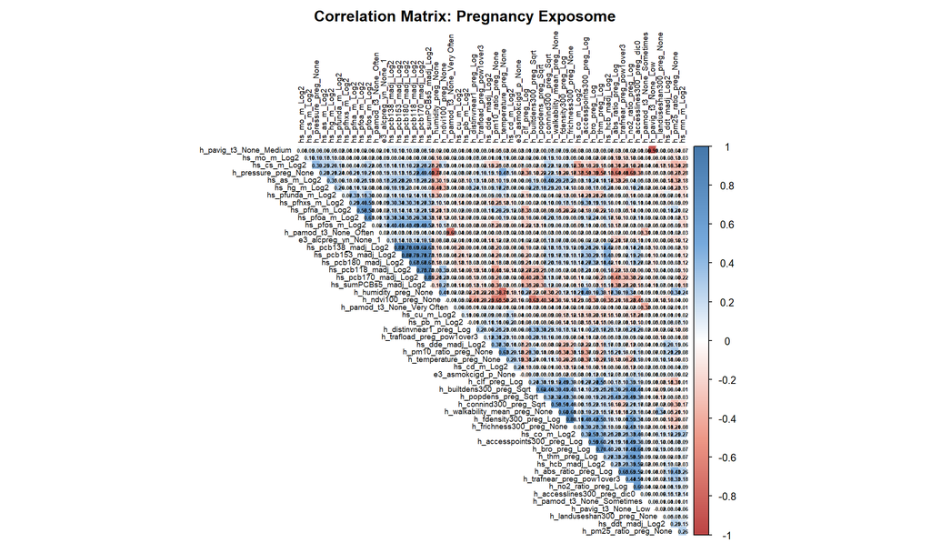

```r
# ------------------------------------------------------------------------------
# BLOCK 4: CORRELATION ANALYSIS (Corrplots)
# ------------------------------------------------------------------------------
message("\n>>> [Block 4] Generating Correlation Plots...")

generate_corrplot <- function(data_mat, plot_title, tl) {

  message(paste("    -> Processing:", plot_title))

  # Calculate Correlation (Pairwise Complete)
  M <- cor(data_mat, use = "pairwise.complete.obs")

  col_palette <- colorRampPalette(c("#BB4444", "#EE9988", "#FFFFFF", "#77AADD", "#4477AA"))

  # Save PDF

  corrplot(M,
           method = "color",
           col = col_palette(200),
           type = "upper",
           order = "hclust",
           addCoef.col = "black",
           tl.col = "black",
           tl.cex = 0.6,
           number.cex = tl,
           diag = FALSE,
           title = plot_title,
           mar = c(0,0,2,0))


}

# Generate plots for all 3 datasets
generate_corrplot(X_preg, "Correlation Matrix: Pregnancy Exposome", tl=0.4)
```

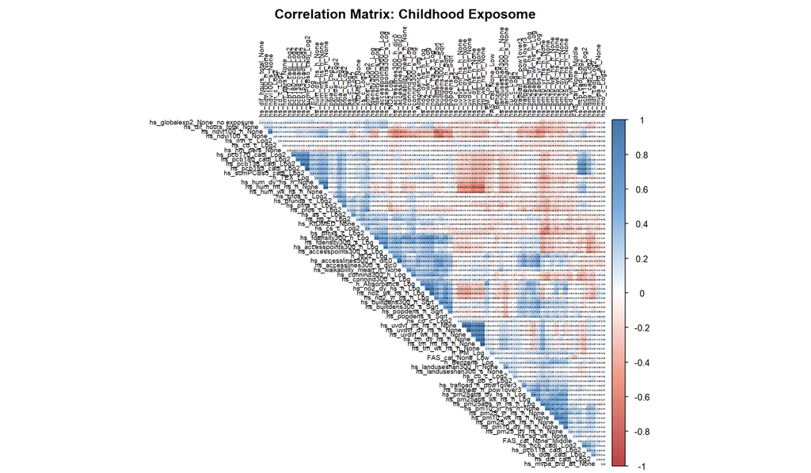

```r
generate_corrplot(X_child, "Correlation Matrix: Childhood Exposome", tl=0.2)
```

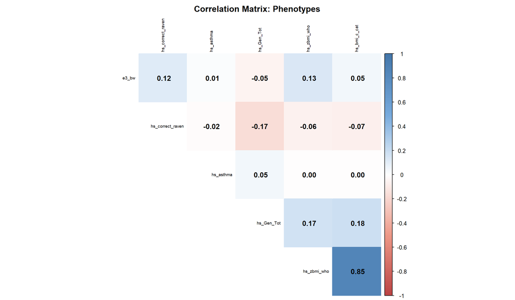

```r
generate_corrplot(Y, "Correlation Matrix: Phenotypes", tl=1)
```

# 6 6. EXPERIMENTAL DESIGN: The Validation Architecture

To prevent overfitting—a critical risk in high-dimensional studies—we implemented a strict **Three-Stage Validation Protocol**.

#### 6.0.0.1 Stage 1: Stratified Discovery Split (80/20)

The population was partitioned into a **Training Set (80%)** for model discovery and a **Test Set (20%)** for independent evaluation.

#### 6.0.0.2 Stage 2: Hyperparameter Tuning (5-Fold Cross-Validation)

Within the Training Set, we optimized the model’s hyperparameters: 1. **The Rank ($r$):** The number of latent biological pathways. 2. **The Penalty ($\lambda$):** The strength of the filter.

We used **5-Fold Cross-Validation (CV)**. The logic for 5-Fold (rather than 10) is to preserve a sufficient number of rare clinical events (e.g., asthma cases) in each validation fold, ensuring a stable estimate of the Deviance.

#### 6.0.0.3 Stage 3: The “Validate-then-Refit” Logic

Once the optimal hyperparameters ($Rank_{opt}, \lambda_{opt}$) were validated (confirmed by low pMSE in the Test Set), we refitted the final model using the **Whole Sample (100%)**.

- **Justification:** In epidemiology, our goal is inference. Using the full sample size maximizes statistical power to estimate the magnitude of the coefficients ($\beta$) accurately, while the previous steps ensured the *structure* of the model is not an artifact.

```r
# ------------------------------------------------------------------------------
# BLOCK 5: DATA SPLITTING & STRATIFICATION (Training/Test & Folds)
# ------------------------------------------------------------------------------
message(">>> [Block 5] Starting Data Splitting and Stratification...")

# 5.1 Configuration
# ------------------------------------------------------------------------------
set.seed(12345)
train_prop <- 0.8
num_folds  <- 5

# 5.2 Create Stratification Variable (Combined Asthma & BMI Category)
# ------------------------------------------------------------------------------
# We combine both variables to ensure balance in both.
# We handle NAs as a separate level so we don't lose any individuals.

# Temporary factors for stratification
s_asthma  <- ifelse(is.na(Y[, "hs_asthma"]), "NA", as.character(Y[, "hs_asthma"]))
s_bmi_cat <- ifelse(is.na(Y[, "hs_bmi_c_cat"]), "NA", as.character(Y[, "hs_bmi_c_cat"]))

# Create the interaction strata
combined_strata <- as.factor(paste(s_asthma, s_bmi_cat, sep = "_"))

message("    Strata distribution (Asthma_BMIcat):")
print(table(combined_strata))
```

```
combined_strata
 0_1  0_2  0_3  0_4  1_1  1_2  1_3  1_4 NA_2 NA_3 NA_4
  11  805  223  115    2   96   29   13    3    1    3
```

```r
# 5.3 Split Population (Training 80% / Test 20%)
# ------------------------------------------------------------------------------
# Using caret::createDataPartition to ensure the 80/20 split is balanced
train_index <- caret::createDataPartition(combined_strata, p = train_prop, list = FALSE)
train_index <- as.vector(train_index)

# Split Exposome
X_preg_train  <- X_preg[train_index, ]
X_preg_test   <- X_preg[-train_index, ]
X_child_train <- X_child[train_index, ]
X_child_test  <- X_child[-train_index, ]

# Split Covariates and Outcomes
Z_train  <- Z[train_index, ]
Z_test   <- Z[-train_index, ]
Y_train  <- Y[train_index, ]
Y_test   <- Y[-train_index, ]

message(paste("    Split complete. Training N:", nrow(Y_train), "| Test N:", nrow(Y_test)))

# 5.4 Generate Stratified Fold IDs for Cross-Validation
# ------------------------------------------------------------------------------
# We repeat the stratification logic inside the Training set for the 5 folds.
train_strata <- combined_strata[train_index]

# Create folds
folds_list <- caret::createFolds(train_strata, k = num_folds, list = TRUE)

# Initialize foldid vector
foldid <- numeric(nrow(Y_train))
for(i in seq_along(folds_list)) {
  foldid[folds_list[[i]]] <- i
}
# ------------------------------------------------------------------------------
# BLOCK 5.5: COMPACT BALANCE VERIFICATION (Fixed Alignment)
# ------------------------------------------------------------------------------
message("\n>>> [Block 5.5] Verifying Balance across Folds (Fixed Table)...")

# Variables to check
check_vars <- c("hs_asthma", "hs_bmi_c_cat")

for (var_ in check_vars) {
  message(paste0("\n--- Proportion Table for: ", var_, " ---"))

  # 1. Identify all possible levels (including NA) across the whole dataset
  # This ensures all tables have the same rows even if a fold is missing a category
  all_levels <- names(table(Y[, var_], useNA = "always"))

  # 2. Function to get consistent proportions per fold
  get_prop <- function(data_vec) {
    tab <- table(factor(data_vec, levels = all_levels, exclude = NULL))
    return(round(prop.table(tab), 3))
  }

  # 3. Build the comparison matrix
  comp_matrix <- sapply(1:num_folds, function(f) {
    get_prop(Y_train[foldid == f, var_])
  })

  # 4. Add the Test Set column
  test_col <- get_prop(Y_test[, var_])
  final_tab <- cbind(comp_matrix, test_col)

  # 5. Formatting
  colnames(final_tab) <- c(paste0("Fold_", 1:num_folds), "Test_Set")
  rownames(final_tab) <- ifelse(is.na(all_levels), "Missing/NA", all_levels)

  print(final_tab)
}
```

```
           Fold_1 Fold_2 Fold_3 Fold_4 Fold_5 Test_Set
0           0.885   0.88  0.885  0.886  0.886    0.898
1           0.115   0.11  0.111  0.105  0.105    0.102
Missing/NA  0.000   0.01  0.005  0.010  0.010    0.000
```

```
           Fold_1 Fold_2 Fold_3 Fold_4 Fold_5 Test_Set
1           0.014  0.005  0.010  0.010  0.014    0.008
2           0.692  0.699  0.697  0.690  0.686    0.703
3           0.192  0.196  0.197  0.195  0.195    0.191
4           0.101  0.100  0.096  0.105  0.105    0.098
Missing/NA  0.000  0.000  0.000  0.000  0.000    0.000
```

```r
# ------------------------------------------------------------------------------
# BLOCK 5.6: FINAL DIMENSIONS & SPLIT SUMMARY
# ------------------------------------------------------------------------------
message("\n>>> Final sample distribution:")
print(table(foldid, dnn = "Fold ID"))
```

```
Fold ID
  1   2   3   4   5
208 209 208 210 210
```

```r
message(paste0("\n    Exposome Matrix (Train): ", nrow(X_child_train), " x ", ncol(X_child_train)))
message(paste0("    Exposome Matrix (Test):  ", nrow(X_child_test), " x ", ncol(X_child_test)))

message("\n>>> [Block 5] Step completed. The proportions are now perfectly aligned.")


# ------------------------------------------------------------------------------
# BLOCK 5.7: TEST SET PREPARATION FOR EVALUATION
# ------------------------------------------------------------------------------
# In a tutorial context, we want the Test Set to have ground truth values
# to calculate prediction metrics (RMSE, R2, etc.) later.

# We check if there are any samples in Y_test that present any NA
full_na_test <- rowSums(is.na(Y_test)) >= 1

if(any(full_na_test)) {
  message(paste(">>> Removing", sum(full_na_test), "subjects from Test set with NA outcome data."))

  X_preg_test  <- X_preg_test[!full_na_test, ]
  X_child_test <- X_child_test[!full_na_test, ]
  Z_test       <- Z_test[!full_na_test, ]
  Y_test       <- Y_test[!full_na_test, ]
}

# Note: Individual NAs within Y_test are fine, but when calculating metrics later,
# we will need to use functions that handle NAs (e.g., cor(..., use = "complete.obs")).

message(">>> Block 5 fully optimized for Model Evaluation.")
```

And we **check final dimensions** of produced datasets:

```r
# ------------------------------------------------------------------------------
# BLOCK 5.8: FINAL DATA INTEGRITY CHECK (Dimensions & Names)
# ------------------------------------------------------------------------------
message("\n>>> [Block 5.8] Final Data Integrity Check before Modeling...")

# 1. List of main datasets to inspect
# ------------------------------------------------------------------------------
datasets_to_check <- list(
  X_preg_train  = X_preg_train,
  X_preg_test   = X_preg_test,
  X_child_train = X_child_train,
  X_child_test  = X_child_test,
  Z_train       = Z_train,
  Z_test        = Z_test,
  Y_train       = Y_train,
  Y_test        = Y_test
)

# 2. Automated Inspection Loop
# ------------------------------------------------------------------------------
for (name in names(datasets_to_check)) {
  mat <- datasets_to_check[[name]]

  # Basic Info
  cat(paste0("\n--- Dataset: ", name, " ---\n"))
  cat(paste0("  [Dim]: ", nrow(mat), " rows x ", ncol(mat), " columns\n"))

  # Column check (First 10)
  all_cols <- colnames(mat)
  n_to_show <- min(10, length(all_cols))
  cat(paste0("  [First ", n_to_show, " vars]: ",
             paste(all_cols[1:n_to_show], collapse = ", "), "...\n"))

  # NA Check (Should be 0 for X and Z, but can have some in Y)
  n_nas <- sum(is.na(mat))
  if(n_nas > 0) {
    cat(paste0("  [Alert]: Found ", n_nas, " missing values (Expected in Y, check if in X/Z)\n"))
  }
}
```

```
--- Dataset: X_preg_train ---
  [Dim]: 1045 rows x 53 columns
  [First 10 vars]: h_abs_ratio_preg_Log, h_no2_ratio_preg_Log, h_pm10_ratio_preg_None, h_pm25_ratio_preg_None, h_accesslines300_preg_dic0, h_accesspoints300_preg_Log, h_builtdens300_preg_Sqrt, h_connind300_preg_Sqrt, h_fdensity300_preg_Log, h_frichness300_preg_None...

--- Dataset: X_preg_test ---
  [Dim]: 249 rows x 53 columns
  [First 10 vars]: h_abs_ratio_preg_Log, h_no2_ratio_preg_Log, h_pm10_ratio_preg_None, h_pm25_ratio_preg_None, h_accesslines300_preg_dic0, h_accesspoints300_preg_Log, h_builtdens300_preg_Sqrt, h_connind300_preg_Sqrt, h_fdensity300_preg_Log, h_frichness300_preg_None...

--- Dataset: X_child_train ---
  [Dim]: 1045 rows x 76 columns
  [First 10 vars]: hs_no2_dy_hs_h_Log, hs_no2_wk_hs_h_Log, hs_no2_yr_hs_h_Log, hs_pm10_dy_hs_h_None, hs_pm10_wk_hs_h_None, hs_pm10_yr_hs_h_None, hs_pm25_dy_hs_h_None, hs_pm25_wk_hs_h_None, hs_pm25_yr_hs_h_None, hs_pm25abs_dy_hs_h_Log...

--- Dataset: X_child_test ---
  [Dim]: 249 rows x 76 columns
  [First 10 vars]: hs_no2_dy_hs_h_Log, hs_no2_wk_hs_h_Log, hs_no2_yr_hs_h_Log, hs_pm10_dy_hs_h_None, hs_pm10_wk_hs_h_None, hs_pm10_yr_hs_h_None, hs_pm25_dy_hs_h_None, hs_pm25_wk_hs_h_None, hs_pm25_yr_hs_h_None, hs_pm25abs_dy_hs_h_Log...

--- Dataset: Z_train ---
  [Dim]: 1045 rows x 11 columns
  [First 10 vars]: h_mbmi_None, e3_gac_None, e3_sex_None, h_age_None, h_cohort_2, h_cohort_3, h_cohort_4, h_cohort_5, h_cohort_6, h_edumc_None_2...

--- Dataset: Z_test ---
  [Dim]: 249 rows x 11 columns
  [First 10 vars]: h_mbmi_None, e3_gac_None, e3_sex_None, h_age_None, h_cohort_2, h_cohort_3, h_cohort_4, h_cohort_5, h_cohort_6, h_edumc_None_2...

--- Dataset: Y_train ---
  [Dim]: 1045 rows x 6 columns
  [First 6 vars]: e3_bw, hs_asthma, hs_zbmi_who, hs_correct_raven, hs_Gen_Tot, hs_bmi_c_cat...
  [Alert]: Found 35 missing values (Expected in Y, check if in X/Z)

--- Dataset: Y_test ---
  [Dim]: 249 rows x 6 columns
  [First 6 vars]: e3_bw, hs_asthma, hs_zbmi_who, hs_correct_raven, hs_Gen_Tot, hs_bmi_c_cat...
```

```r
# 3. Validation Fold (foldid) Check
# ------------------------------------------------------------------------------
cat("\n--- CV Folds (foldid) ---\n")
```

```
--- CV Folds (foldid) ---
```

```r
cat(paste0("  Length: ", length(foldid), " (Matches Y_train: ", length(foldid) == nrow(Y_train), ")\n"))
```

```
  Length: 1045 (Matches Y_train: TRUE)
```

```r
cat("  Frequency per fold:\n")
```

```
  Frequency per fold:
```

```r
print(table(foldid))
```

```
foldid
  1   2   3   4   5
208 209 208 210 210
```

```r
message("\n>>> [Integrity Check] Done. All datasets are aligned and ready.")
```

# 7 7. DATA HARMONIZATION: The “Leakage-Proof” Strategy and Mathematical Fairness

## 7.1 7.1 Why Standardization & Scaling Matter

**The Problem**: In exposome research, variables are measured in vastly different units (e.g., μg/L for blood chemicals vs. meters for proximity to green spaces). Because the msRRR model applies a strict Group-Lasso regularization penalty ($\lambda$) to filter variables, it would mathematically penalize exposures with naturally larger numerical ranges. Similarly, health outcomes span different domains (e.g., continuous metrics vs. binary status), risking that high-variance outcomes dominate the latent factors.

**The Solution**: We harmonize the data before modeling to ensure all variables compete equally for selection:

- **Predictors ($X$) & Covariates ($Z$)**: Z-score standardization ($\mu=0$, $\sigma=1$).
- **Continuous Outcomes ($Y$)**: Min-Max scaling to unify them into a strict $[0-1]$ range.
- **Binary Outcomes ($Y$)**: Explicit binarization (e.g., thresholding BMI categories strictly into 0 and 1).

## 7.2 7.2 Preventing Data Leakage (The Correct Implementation)

A common methodological flaw in machine learning pipelines is **Data Leakage**—scaling the *entire* dataset before splitting it into Training and Test sets. If standardizations are applied globally, information from the Test set “leaks” into the Training set through the global mean, standard deviation, or max values. This leads to mathematically biased models and over-optimistic validation metrics.

To ensure strict integrity and true external validity, we implemented a **Leakage-Proof harmonization strategy**:

1. **Learn Parameters exclusively from Training Data**: The scaling attributes (mean, SD, minimum, and maximum values) are calculated *only* using the subjects within the 80% Training partition (`X_train`, `Y_train`, `Z_train`).
2. **Apply to Unseen Data**: These specific parameters learned from the Training set are subsequently applied to scale the Test set.

This rigorous approach guarantees that the Test set remains completely naive and unseen, preserving the mathematical fairness of the regularization step.

```r
# ------------------------------------------------------------------------------
# BLOCK 5.9: STANDARDIZATION & SCALING (Corrected for Data Leakage)
# ------------------------------------------------------------------------------
message(">>> [Block 5.9] Standardizing predictors (Z-score) and scaling outcomes [0-1]...")

# A. Helper function for Z-score (Predictors X and Covariates Z)
# ------------------------------------------------------------------------------
# We calculate Mean and SD on Train, then apply to both Train and Test.
standardize_pair <- function(train_mat, test_mat) {
  # Standardize Train and save the attributes (center and scale)
  train_scaled <- scale(train_mat)
  center_val   <- attr(train_scaled, "scaled:center")
  scale_val    <- attr(train_scaled, "scaled:scale")

  # Standardize Test using Train's parameters
  test_scaled  <- scale(test_mat, center = center_val, scale = scale_val)

  return(list(train = train_scaled, test = test_scaled))
}

# Apply to Exposome and Covariates
res_preg  <- standardize_pair(X_preg_train, X_preg_test)
X_preg_train <- res_preg$train; X_preg_test <- res_preg$test

res_child <- standardize_pair(X_child_train, X_child_test)
X_child_train <- res_child$train; X_child_test <- res_child$test

res_z     <- standardize_pair(Z_train, Z_test)
Z_train <- res_z$train; Z_test <- res_z$test


# B. Helper function for [0-1] Scaling (Outcomes Y)
# ------------------------------------------------------------------------------
# We use Min and Max from Train to scale both sets.
scale_01_pair <- function(train_mat, test_mat) {
  # Copy structures
  sc_train <- train_mat
  sc_test  <- test_mat

  for (col in colnames(train_mat)) {
    # Only scale if variable is not binary (more than 2 unique values)
    if (length(unique(na.omit(train_mat[, col]))) > 2) {
      min_val <- min(train_mat[, col], na.rm = TRUE)
      max_val <- max(train_mat[, col], na.rm = TRUE)
      range_val <- max_val - min_val

      if (range_val > 0) {
        sc_train[, col] <- (train_mat[, col] - min_val) / range_val
        sc_test[, col]  <- (test_mat[, col] - min_val) / range_val
      }
    }
  }
  return(list(train = sc_train, test = sc_test))
}

# Apply to Outcomes
res_y <- scale_01_pair(Y_train, Y_test)
Y_train <- res_y$train; Y_test <- res_y$test


# C. Specific Binarization: BMI Category
# ------------------------------------------------------------------------------
# 0 (Under+Normal) vs 1 (Over+Obese)
# After [0-1] scaling, the threshold 0.5 separates the groups correctly.
Y_train[, "hs_bmi_c_cat"] <- as.numeric(Y_train[, "hs_bmi_c_cat"] > 0.5)
Y_test[, "hs_bmi_c_cat"]  <- as.numeric(Y_test[, "hs_bmi_c_cat"] > 0.5)


# ------------------------------------------------------------------------------
# FINAL CHECKS
# ------------------------------------------------------------------------------
message("\n--- Scaling Verification (Train Set) ---")
print(apply(Y_train, 2, range, na.rm = TRUE))
```

```
     e3_bw hs_asthma hs_zbmi_who hs_correct_raven hs_Gen_Tot hs_bmi_c_cat
[1,]     0         0           0                0          0            0
[2,]     1         1           1                1          1            1
```

```r
message("\n--- BMI Binarization Check (Test Set) ---")
print(table(Y_test[, "hs_bmi_c_cat"], dnn = "BMI_Binary"))
```

```
BMI_Binary
  0   1
176  73
```

# 8 8. HYPERPARAMETER OPTIMIZATION: The Tune-Validate-Refit Logic

With the data strictly harmonized and secured against Data Leakage, we proceed to awaken the **msRRR** statistical engine. In this phase, the algorithm does not merely fit a single model; it explores a vast hyperparameter space to find the perfect equilibrium between biological complexity (Latent Rank $r$) and strict variable selection (Group-Lasso Penalty $\lambda$).

To capture the complexity of exposures across different developmental windows, we will sequentially evaluate three scenarios: **A) Pregnancy Exposome**, **B) Childhood Exposome**, and **C) Combined Exposome**.

## 8.1 8.1 The “Mixed-Response” Architecture and hyperparameter tunning

The true advantage of the msRRR framework is its multivariate, *Outcome-Wide* capability. Through the `family` and `familygroup` arguments, we mathematically map the statistical nature of each outcome into a single, unified response matrix. Continuous phenotypes (such as Birthweight or BMI z-score) are evaluated under a Gaussian link, while categorical phenotypes (such as Asthma status) are processed using a Binomial (Logit) link.

msRRR requires tuning **two hyperparameters**: - **Rank (r)**: Number of latent biological pathways (typically 2-8) - **Lambda (λ)**: Sparsity strength (controls how many exposures are selected)

**Why 5-Fold instead of 10-Fold?** - With 10 folds on rare outcomes (Asthma ~10%), validation folds contain 0-1 cases - Creates extreme variance in error estimates - 5-fold preserves sufficient rare events per fold

## 8.2 8.2 The Regularization Path: Defining $\lambda_{max}$ and the Sparsity Sequence

Before the model can select which exposures matter, it needs to define its “search grid” for penalization. To guarantee maximum computational efficiency and mathematical precision, we dynamically calculate the exact starting point of the penalty:

**Lambda Search Space**: - Theoretical start: λ_max from KKT conditions (all coefficients → zero) - Logarithmic sequence down to λ_min = λ_max × 10^-4 - Gives fine resolution where variables actually enter the model

1. **The Penalty Ceiling ($\lambda_{max}$):** Based on the Karush-Kuhn-Tucker (KKT) conditions, we calculate the exact point where the Group-Lasso penalty is so severe that all exposome coefficients shrink to absolute zero. This is achieved by extracting the spectral norm (the largest singular value) from the cross-product matrix ($X^TY$). A 10% numerical safety margin (`* 1.1`) is added to ensure that the regularization path strictly begins at the Null Model.
2. **The Logarithmic Sequence:** Starting from $\lambda_{max}$, we generate a geometric (logarithmic) progression of 100 values. Penalized models are extremely sensitive at low $\lambda$ values (where variables first enter the model). This logarithmic scale provides “surgical” resolution right at the critical elbow of the regularization path. The chosen depth (`1e-4`) allows the model to explore denser networks if the signals are weak, which is ideal for capturing small, pleiotropic environmental effects.

## 8.3 8.3 Cross-Validation and Predictive Performance (pMSE)

For each scenario, the model is trained using **K-fold Cross-Validation** (based on the stratified folds generated previously). The algorithm simultaneously evaluates multiple latent dimensions (`nrankseq = 2:4`) and the entire $\lambda$ sequence, ultimately **selecting the rank/lambda combination that minimizes the chosen CV criterion**. By default, we keep `cv.criteria = "deviance"` to preserve the original mixed-response analysis. If all final outcomes are continuous, this can be switched to `cv.criteria = "pMSE"`; because this changes the selection criterion, the models must be re-run.

## 8.4 8.4 Validating on Unseen Data

Finally, we extract these optimal parameters and calculate the **pseudo Mean Squared Error (pMSE)** on both the Training partition and the unseen Test set. This pMSE is reported as a common predictive performance metric, even when deviance is used for CV selection. A low difference between these two metrics (`Perf_Dif`) will empirically confirm that our model has extracted real, generalizable biological patterns, successfully avoiding overfitting.

- Apply fixed (rank*, λ*) to predict Y_test from X_test
- Calculate prediction error (pMSE)
- If error is low, structure is valid; if high, model is overfitted

This validates that the model learned real patterns, not noise.

```r
# ------------------------------------------------------------------------------
# BLOCK 6: msRRR MODEL FITTING (Sequential Scenarios)
# ------------------------------------------------------------------------------
message(">>> [Block 6] Fitting Models for Pregnancy, Childhood, and Combined...")

# 6.0 Shared Model Configuration
# ------------------------------------------------------------------------------
# Outcome Family Mapping:
# 1: Birthweight (Gaussian), 2: Asthma (Binomial), 3: zBMI (Gaussian),
# 4: Raven (Gaussian), 5: Gen_Health (Gaussian), 6: Binary BMI Cat (Binomial)
outcome_families <- list(gaussian(), binomial())
family_mapping   <- c(1, 2, 1, 1, 1, 2)
n_obs            <- nrow(Y_train)

# TECHNICAL NOTE ON MEAN IMPUTATION FOR LAMBDA CALCULATION:
# The svd() function and crossprod() cannot handle missing values (NA).
# To calculate the gradient at zero (lambda_max), we temporarily replace NAs
# in Y with the column means. This represents the most neutral statistical
# assumption, effectively zeroing out the influence of missing observations
# in the cross-product matrix.
Y_imputed <- Y_train
for(i in 1:ncol(Y_imputed)) {
  col_mean <- mean(Y_imputed[, i], na.rm = TRUE)
  Y_imputed[is.na(Y_imputed[, i]), i] <- col_mean
}

# ------------------------------------------------------------------------------
# 6.1 SCENARIO A: PREGNANCY EXPOSOME ONLY
# ------------------------------------------------------------------------------
message("\n>>> Scenario A: Fitting Pregnancy Model...")

# TECHNICAL RATIONALE FOR LAMBDA_MAX:
# Based on Karush-Kuhn-Tucker (KKT) conditions, lambda_max is the point where
# all coefficients shrink to zero. We calculate this as the spectral norm
# (largest singular value) of the cross-product (X'Y), normalized by n.
C_preg          <- crossprod(X_preg_train, Y_imputed)
spec_norm_preg  <- svd(C_preg, nu = 0, nv = 0)$d[1]
lam_max_preg    <- (spec_norm_preg / n_obs) * 1.1 #The 1.1 factor provides a numerical safety margin to ensure the regularization path begins strictly at the Null Model.
# It accounts for potential floating-point inaccuracies, guaranteeing that all exposure coefficients start at exactly zero.

# TECHNICAL RATIONALE FOR LOGARITHMIC SEQUENCE:
# We use a 10^seq(log10...) approach to generate a geometric progression.
# Penalized models are highly sensitive at low lambda values (where variables
# enter the model) and less sensitive at high values. A logarithmic sequence
# provides higher resolution for the critical "elbow" of the regularization path.
# Depth of 1e-4 will define how close to the lambda max we finish the sequence. It allows for the inclusion of denser models if the signal is weak. Decreasing it to 1e-6 forces the model to include more variables (higher sensitivity for weak signals),
# while increasing it to 1e-2 restricts selection to only the strongest predictors (higher specificity).
# For epidemiologists, use a larger depth if you expect many small, pleiotropic effects,
# and a smaller depth if the goal is to identify a few dominant environmental drivers.
lam_seq_preg <- 10^(seq(log10(lam_max_preg), log10(lam_max_preg * 1e-4), length.out = 100))
cv.crit_preg <- "deviance"
# cv.crit_preg <- "pMSE"

fit_preg <- msrrr(
  Y = Y_train, X = X_preg_train, Z = Z_train,
  family = outcome_families, familygroup = family_mapping,
  nrankseq = 2:4, lamseq = lam_seq_preg,
  foldid = foldid, method = 'CV', cv.criteria = cv.crit_preg, warm = TRUE
)


# ------------------------------------------------------------------------------
# 6.2 SCENARIO B: CHILDHOOD EXPOSOME ONLY
# ------------------------------------------------------------------------------
message("\n>>> Scenario B: Fitting Childhood Model...")

# Recalculating lambda_max for the Childhood covariate structure
C_child         <- crossprod(X_child_train, Y_imputed)
spec_norm_child <- svd(C_child, nu = 0, nv = 0)$d[1]
lam_max_child   <- (spec_norm_child / n_obs) * 1.1
lam_seq_child   <- 10^(seq(log10(lam_max_child), log10(lam_max_child * 1e-4), length.out = 100))
cv.crit_child <- "deviance"
# cv.crit_child <- "pMSE"

fit_child <- msrrr(
  Y = Y_train, X = X_child_train, Z = Z_train,
  family = outcome_families, familygroup = family_mapping,
  nrankseq = 2:4, lamseq = lam_seq_child,
  foldid = foldid, method = 'CV', cv.criteria = cv.crit_child, warm = TRUE
)

# ------------------------------------------------------------------------------
# 6.3 SCENARIO C: COMBINED EXPOSOME (Pregnancy + Childhood)
# ------------------------------------------------------------------------------
message("\n>>> Scenario C: Fitting Combined Model...")

# Concatenating sources to evaluate joint effects
X_combined_train <- cbind(X_preg_train, X_child_train)

# Recalculating lambda_max for the joint dimension
C_comb          <- crossprod(X_combined_train, Y_imputed)
spec_norm_comb  <- svd(C_comb, nu = 0, nv = 0)$d[1]
lam_max_comb    <- (spec_norm_comb / n_obs) * 1.1
lam_seq_comb    <- 10^(seq(log10(lam_max_comb), log10(lam_max_comb * 1e-4), length.out = 100))
cv.crit_comb <- "deviance"
# cv.crit_comb <- "pMSE"

fit_comb <- msrrr(
  Y = Y_train, X = X_combined_train, Z = Z_train,
  family = outcome_families, familygroup = family_mapping,
  nrankseq = 2:4, lamseq = lam_seq_comb,
  foldid = foldid, method = 'CV', cv.criteria = cv.crit_comb, warm = TRUE
)


# ------------------------------------------------------------------------------
# BLOCK 7.1: INITIALIZE RESULTS SUMMARY TABLE
# ------------------------------------------------------------------------------
message(">>> [Block 7.1] Summarizing Model Results...")

# 1. Prepare Joint Test Matrix for Scenario C
X_combined_test <- cbind(X_preg_test, X_child_test)

# 2. Initialize the results dataframe
results_df <- data.frame(
  Scenario      = c("Pregnancy", "Childhood", "Combined"),
  Seed          = rep(12345, 3),
  Opt_Rank      = rep(NA, 3),
  Opt_Lambda    = rep(NA, 3),
  N_Exposures   = rep(NA, 3),
  CV_Crit_Name  = c(cv.crit_preg, cv.crit_child, cv.crit_comb),
  CV_Crit_Value = rep(NA, 3),
  pMSE_training = rep(NA, 3),
  pMSE_test     = rep(NA, 3)
)

# 3. Helper function to fill the table
fill_results <- function(row_idx, model_obj) {
  results_df$Opt_Rank[row_idx]    <<- model_obj$nrank
  results_df$Opt_Lambda[row_idx]  <<- model_obj$lam.opt
  # Count selected predictors (non-zero coefficients in B matrix)
  results_df$N_Exposures[row_idx] <<- sum(rowSums(model_obj$fit$B != 0) > 0)
  # Extract the minimum selected CV criterion value from the tuning path
  results_df$CV_Crit_Value[row_idx] <<- min(unlist(model_obj$tunepath.opt), na.rm = TRUE)
}

fill_results(1, fit_preg)
fill_results(2, fit_child)
fill_results(3, fit_comb)
```

## 8.5 8.5 Visualizing the Optimization Space: Diagnostic Plots

After cross-validation, it is essential to visually verify the model’s learning behavior to ensure it has reached a stable global optimum rather than a localized artifact. We generate two key diagnostic plots:

1. **Rank vs. selected CV criterion:** This evaluates the structural complexity of the model. It shows how increasing the number of latent factors (biological pathways) affects the selected CV metric (`deviance` by default, or `pMSE` if selected). The optimal rank sits at the “elbow,” capturing maximum variance without overfitting.
2. **The Regularization Path (Lambda):** For the optimal rank, we plot the selected CV criterion across all CV folds for the entire logarithmic $\lambda$ sequence. This visualizes the classic bias-variance tradeoff. A well-behaved path will show a clear minimum, confirming that the Group-Lasso penalty has successfully filtered out the noise.

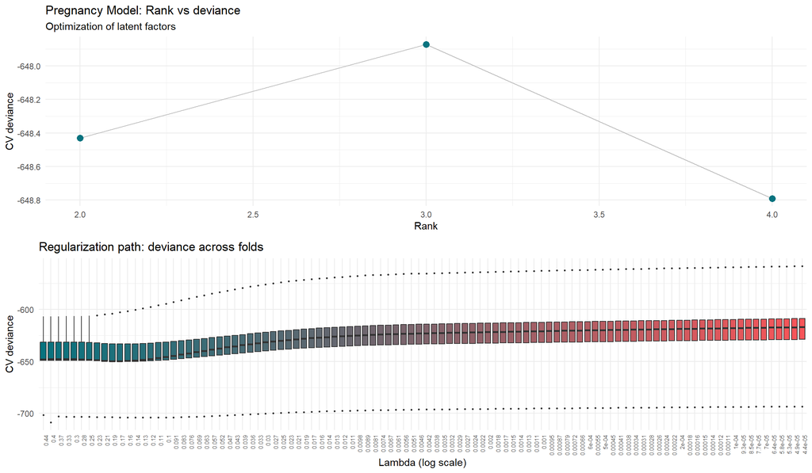

```r
# ------------------------------------------------------------------------------
# BLOCK 7.3: DIAGNOSTIC PLOTS (Generalized Function)
# ------------------------------------------------------------------------------

message(">>> [Block 7.3] Defining and generating Diagnostic Plots...")

# Function to generate Rank and Lambda diagnostics for any scenario
generate_diagnostics <- function(model_obj, scenario_name, cv.crit) {

  # 1. Rank vs selected CV metric plot
  rank_data <- data.frame(
    Rank = model_obj$nrankseq,
    CV_metric = unlist(model_obj$tunepath.opt)
  )

  p_rank <- ggplot(rank_data, aes(x = Rank, y = CV_metric)) +
    geom_line(color = "grey") +
    geom_point(size = 3, color = "#08737f") +
    theme_minimal() +
    labs(
      title = paste(scenario_name, "Model: Rank vs", cv.crit),
      subtitle = "Optimization of latent factors",
      x = "Rank",
      y = paste("CV", cv.crit)
    )

  # 2. Lambda boxplot for the optimal rank
  opt_rank_name <- paste0("nrank_", model_obj$nrank)

  # Extract fold data, removing the summary column
  dtplot_raw <- model_obj$Tunepath[[opt_rank_name]]
  dtplot_folds <- t(dtplot_raw[, -ncol(dtplot_raw), drop = FALSE])

  colnames(dtplot_folds) <- sprintf("%.1e", model_obj$lamseq)

  dtplot_long <- reshape2::melt(dtplot_folds)
  dtplot_long$Var2 <- factor(dtplot_long$Var2, levels = unique(dtplot_long$Var2))

  my_colors <- colorRampPalette(c("#08737f", "#f95559"))(100)

  p_lambda <- ggplot(dtplot_long, aes(x = Var2, y = value, fill = Var2)) +
    geom_boxplot(outlier.size = 0.5) +
    scale_fill_manual(values = my_colors) +
    theme_minimal() +
    theme(
      axis.text.x = element_text(angle = 90, size = 6, hjust = 1),
      legend.position = "none"
    ) +
    labs(
      x = "Lambda (log scale)",
      y = paste("CV", cv.crit),
      title = paste("Regularization path:", cv.crit, "across folds")
    )

  # Return as grob, without drawing immediately
  return(gridExtra::arrangeGrob(p_rank, p_lambda, ncol = 1))
}

# Example: Generate plots for each scenario
diag_preg  <- generate_diagnostics(fit_preg, "Pregnancy", cv.crit = cv.crit_preg)
diag_child <- generate_diagnostics(fit_child, "Childhood", cv.crit = cv.crit_child)
diag_comb  <- generate_diagnostics(fit_comb, "Combined", cv.crit = cv.crit_comb)


plot(diag_preg)
```

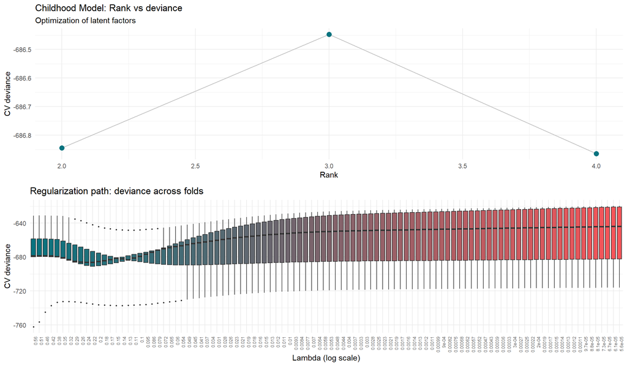

```r
plot(diag_child)
```

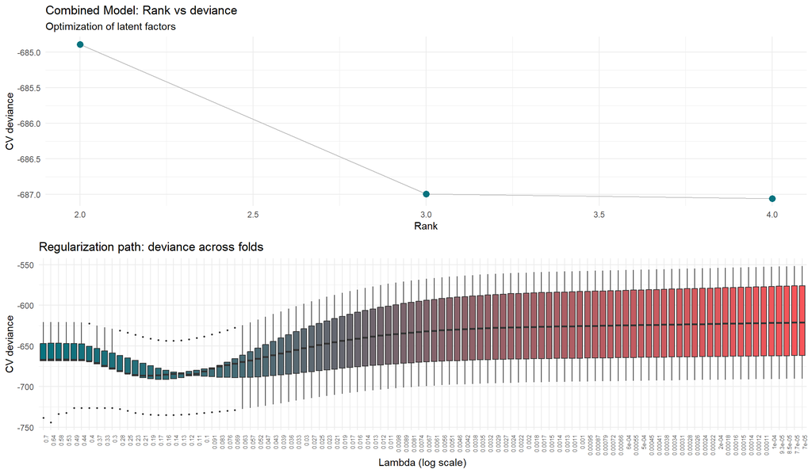

```r
plot(diag_comb)
```

Finally, we extract these optimal parameters and calculate the **pseudo Mean Squared Error (pMSE)** on both the Training partition and the unseen Test set.

```r
# ------------------------------------------------------------------------------
# BLOCK 7.2: PREDICTION PERFORMANCE (pMSE)
# ------------------------------------------------------------------------------
message(">>> [Block 7.2] Calculating pMSE for Training and Test sets...")

# Scenario A: Pregnancy
fit_train_preg <- predict.msrrr(fit_preg, Y.new = Y_train, X.new = X_preg_train, Z = Z_train, family=outcome_families, familygroup=family_mapping, cv.criteria="pMSE")
fit_test_preg  <- predict.msrrr(fit_preg, Y.new = Y_test,  X.new = X_preg_test,  Z = Z_test,  family=outcome_families, familygroup=family_mapping, cv.criteria="pMSE")
results_df$pMSE_training[1] <- fit_train_preg$pred.perf
results_df$pMSE_test[1]     <- fit_test_preg$pred.perf

# Scenario B: Childhood
fit_train_child <- predict.msrrr(fit_child, Y.new = Y_train, X.new = X_child_train, Z = Z_train, family=outcome_families, familygroup=family_mapping, cv.criteria="pMSE")
fit_test_child  <- predict.msrrr(fit_child, Y.new = Y_test,  X.new = X_child_test,  Z = Z_test,  family=outcome_families, familygroup=family_mapping, cv.criteria="pMSE")
results_df$pMSE_training[2] <- fit_train_child$pred.perf
results_df$pMSE_test[2]     <- fit_test_child$pred.perf

# Scenario C: Combined
fit_train_comb <- predict.msrrr(fit_comb, Y.new = Y_train, X.new = X_combined_train, Z = Z_train, family=outcome_families, familygroup=family_mapping, cv.criteria="pMSE")
fit_test_comb  <- predict.msrrr(fit_comb, Y.new = Y_test,  X.new = X_combined_test,  Z = Z_test,  family=outcome_families, familygroup=family_mapping, cv.criteria="pMSE")
results_df$pMSE_training[3] <- fit_train_comb$pred.perf
results_df$pMSE_test[3]     <- fit_test_comb$pred.perf

results_df$Perf_Dif <- abs(results_df$pMSE_training - results_df$pMSE_test)

print(results_df)
```

```
   Scenario  Seed Opt_Rank Opt_Lambda N_Exposures CV_Crit_Name CV_Crit_Value
1 Pregnancy 12345        4  0.4029361          12     deviance     -648.7897
2 Childhood 12345        4  0.1656406          19     deviance     -686.8643
3  Combined 12345        4  0.1448532          26     deviance     -687.0567
  pMSE_training pMSE_test    Perf_Dif
1     0.7690492 0.7794487 0.010399482
2     0.7414421 0.7475394 0.006097341
3     0.7423578 0.7481753 0.005817561
```

## 8.6 8.6 The Outcome-Wide Environmental Signature: Global Heatmaps

This block generates the culmination of the training phase: the global coefficient matrix ($\mathbf{B}$). By visualizing all exposures and all outcomes simultaneously, we can identify **pleiotropic environmental factors**—exposures that act as “master drivers,” impacting multiple biological domains at once.

**Methodological Note on Interpretation:** Because we strictly harmonized our data beforehand, the coefficients ($\beta$) are highly interpretable: * **Continuous Outcomes (Gaussian):** Since predictors are Z-scored and outcomes are scaled $[0-1]$, a $\beta = 0.10$ means that a 1 Standard Deviation (SD) increase in the exposure is associated with a 10% shift across the total biological range of the outcome. * **Binary Outcomes (Binomial):** These use a Logit link. Here, $\beta$ represents the change in the log-odds of the disease per 1 SD increase in the exposure ($e^\beta = Odds Ratio$). * *Are they comparable?* While mathematically on different scales (Linear vs. Logit), the penalty treats them equally. A strong signal across both domains indicates a powerful, systemic environmental driver.

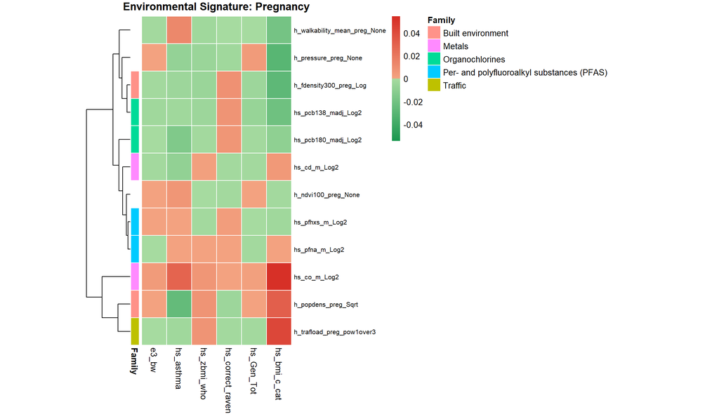

```r
# ------------------------------------------------------------------------------
# BLOCK 8: PROFESSIONAL COEFFICIENT HEATMAPS (With Interpretation Guide)
# ------------------------------------------------------------------------------

message(">>> [Block 8] Generating custom heatmaps and documentation...")

# 8.0 TECHNICAL NOTE: INTERPRETING msRRR COEFFICIENTS (Beta)
# ------------------------------------------------------------------------------
# 1. CONTINUOUS OUTCOMES (e.g., Birthweight, zBMI):
#    Since outcomes were scaled [0-1] and predictors were standardized (Z-score),
#    Beta represents the change in the outcome range (0 to 1) for every
#    1 standard deviation (SD) increase in the exposure, adjusted for covariates.
#    - Beta = 0.1 means: "1 SD increase in exposure is associated with a 10%
#      increase in the total range of the outcome."
#
# 2. BINARY OUTCOMES (e.g., Asthma, BMI Category):
#    These use a Logit link. Beta represents the change in the LOG-ODDS of
#    the outcome for every 1 SD increase in exposure.
#    Exp(Beta) would provide the Odds Ratio (OR).
#    Beta = 0.4 means: OR = exp(0.4) ≈ 1.50 (a 50% increase in risk).

# 3. ARE EFFECT SIZES COMPARABLE?
#    Technically, NO. Beta_gaussian and Beta_binomial are on different scales
#    (Linear vs. Logit). However, within this msRRR framework, they are
#    comparable in terms of "Selection Strength": the penalty treats them
#    similarly to find the most influential predictors across all domains. A strong color in both indicates the exposure is a powerful
#      driver for both health domains, regardless of the unit.
# ------------------------------------------------------------------------------


# 8.1 CUSTOM COLOR PALETTE (Red-Yellow-Green)
# ------------------------------------------------------------------------------
# We create a palette where:
# - Deep Red: Strong Negative
# - Light Red/Yellow: Approaching Zero (Negative)
# - Pure Yellow: EXACTLY ZERO
# - Light Green/Yellow: Approaching Zero (Positive)
# - Deep Green: Strong Positive
# This ensures that "Yellow" is only seen at the sparsity threshold.

# 8.1 CUSTOM "SHARP" COLOR PALETTE (Verdes y Rojos)
# ------------------------------------------------------------------------------
# Definimos dos rampas que NO pasan por el blanco/amarillo hasta el final.
# Negativo (Verde): De Verde oscuro a Verde muy claro
neg_palette <- colorRampPalette(c("#1A9850", "#A6DBA0"))(50)
# Neutral: Amarillo (Solo para el CERO absoluto)
zero_color  <- "grey"
# Positivo (Rojo): De Rojo muy claro a Rojo oscuro
pos_palette <- colorRampPalette(c("#F4A582", "#D73027"))(50)

custom_colors_pro <- c(neg_palette, zero_color, pos_palette)

# 8.2 CUSTOM BREAKS (La clave para evitar los blancos)
# ------------------------------------------------------------------------------
get_pro_breaks <- function(mat) {
  limit <- max(abs(mat), na.rm = TRUE)
  if(limit == 0) limit <- 0.1

  # Creamos una secuencia que va desde el límite hasta un valor ínfimo (1e-5)
  # Esto deja al color central (grey) un espacio casi invisible,
  # obligando a que cualquier valor pequeño tenga color.
  eps <- 1e-99
  breaks <- c(
    seq(-limit, -eps, length.out = 51), # 50 intervalos negativos
    0,                                  # El punto cero exacto
    seq(eps, limit, length.out = 51)    # 50 intervalos positivos
  )
  return(unique(sort(breaks)))
}

# 8.3 HEATMAP GENERATION FUNCTION
# ------------------------------------------------------------------------------
plot_final_heatmap <- function(model_obj, X_matrix, scenario_name) {

  B_mat <- model_obj$fit$B
  rownames(B_mat) <- colnames(X_matrix)
  colnames(B_mat) <- colnames(Y_train)

  # Filtramos filas donde TODAS las celdas sean exactamente 0
  active_rows <- rowSums(B_mat != 0) > 0
  coef_subset <- B_mat[active_rows, , drop = FALSE]

  if(nrow(coef_subset) == 0) return(NULL)

  # Anotaciones
  clean_names <- gsub("_None|_Ter_2|_Ter_3", "", rownames(coef_subset))
  row_info <- vars_info %>%
    filter(variable_name %in% clean_names) %>%
    distinct(variable_name, .keep_all = TRUE)

  df_row_ann <- data.frame(
    Family = row_info$family[match(clean_names, row_info$variable_name)],
    row.names = rownames(coef_subset)
  )

  if(scenario_name == "Combined") {
    df_row_ann$Period <- ifelse(rownames(coef_subset) %in% colnames(X_preg_train),
                                "Pregnancy", "Childhood")
  }

  pheatmap(
    coef_subset,
    main = paste("Environmental Signature:", scenario_name),
    color = custom_colors_pro,
    breaks = get_pro_breaks(coef_subset),
    annotation_row = df_row_ann,
    cluster_cols = FALSE,
    cluster_rows = TRUE,
    border_color = "white",
    fontsize_row = 8,
    cellwidth = 30
  )
}

# 8.4 Export
# ------------------------------------------------------------------------------

plot_final_heatmap(fit_preg, X_preg_train, "Pregnancy")
```

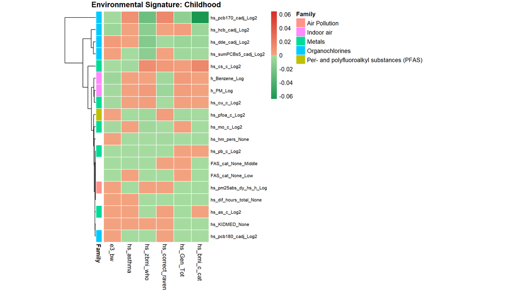

```r
plot_final_heatmap(fit_child, X_child_train, "Childhood")
```

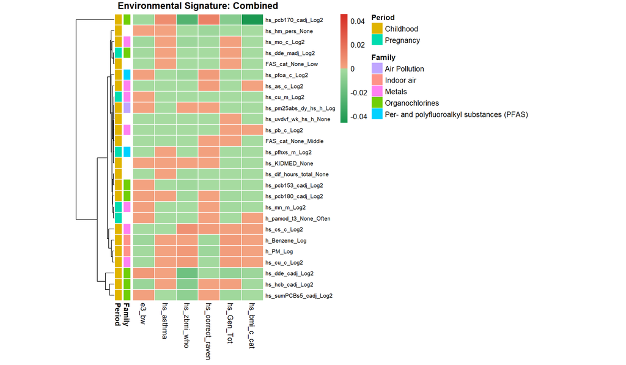

```r
X_comb_train <- cbind(X_preg_train, X_child_train)
plot_final_heatmap(fit_comb, X_comb_train, "Combined")
```

```r
message(">>> Block 8 Complete. Heatmaps updated with non-linear scale.")
```

# 9 9. WHOLE SAMPLE REFIT FOR MAXIMUM INFERENCE POWER

Once the optimal hyperparameters ($Rank_{opt}, \lambda_{opt}$) were validated (confirmed by low pMSE in the Test Set), we refitted the final model using the **Whole Sample (100%)**.

## 9.1 9.1 The “Validate-then-Refit” Logic

**Key Principle**: In epidemiology, we seek **biological inference**, not prediction.

Once the structure (rank*, λ*) is validated on the test set, we refit using **100% of the data** to: - Maximize statistical power for coefficient estimation - Provide the most accurate effect size estimates - Trust coefficients because structure is already validated

This maximizes information without introducing bias.

```r
# ------------------------------------------------------------------------------
# BLOCK 9: WHOLE SAMPLE REFITTING
# ------------------------------------------------------------------------------
message(">>> [Block 9] Refitting models using the WHOLE SAMPLE...")
# ------------------------------------------------------------------------------
set.seed(12345)
# 9.1 Prepare Whole Sample Matrices
# ------------------------------------------------------------------------------
# Standardize the full set (internally consistent for the final model)
X_preg_whole  <- scale(X_preg)
X_child_whole <- scale(X_child)
Z_whole       <- scale(Z)
outcome_families <- list(gaussian(), binomial())
family_mapping   <- c(1, 2, 1, 1, 1, 2)

# Scale Y [0-1] for the whole sample
Y_whole <- Y
for (col in colnames(Y_whole)) {
  if (length(unique(na.omit(Y_whole[, col]))) > 2) {
    min_val <- min(Y_whole[, col], na.rm = TRUE)
    max_val <- max(Y_whole[, col], na.rm = TRUE)
    Y_whole[, col] <- (Y_whole[, col] - min_val) / (max_val - min_val)
  }
}
Y_whole[, "hs_bmi_c_cat"] <- as.numeric(Y_whole[, "hs_bmi_c_cat"] > 0.5)

# 9.2 Refit Final Models (using msrrr.fit for fixed parameters)
# ------------------------------------------------------------------------------
# Scenario A: Pregnancy
fit_preg_whole <- msrrr.fit(
  Y = Y_whole, X = X_preg_whole, Z = Z_whole,
  family = outcome_families, familygroup = family_mapping,
  nrank = results_df$Opt_Rank[1], lambda = results_df$Opt_Lambda[1]
)

# Scenario B: Childhood
fit_child_whole <- msrrr.fit(
  Y = Y_whole, X = X_child_whole, Z = Z_whole,
  family = outcome_families, familygroup = family_mapping,
  nrank = results_df$Opt_Rank[2], lambda = results_df$Opt_Lambda[2]
)

# Scenario C: Combined
X_comb_whole <- cbind(X_preg_whole, X_child_whole)
fit_comb_whole <- msrrr.fit(
  Y = Y_whole, X = X_comb_whole, Z = Z_whole,
  family = outcome_families, familygroup = family_mapping,
  nrank = results_df$Opt_Rank[3], lambda = results_df$Opt_Lambda[3]
)


# ------------------------------------------------------------------------------
# BLOCK 9.4: SUMMARY TABLE FOR WHOLE SAMPLE MODELS
# ------------------------------------------------------------------------------
message(">>> [Block 9.4] Creating summary table for Whole Sample Models...")

# Initialize the dataframe
results_whole_df <- data.frame(
  Scenario      = c("Pregnancy", "Childhood", "Combined"),
  Opt_Rank      = results_df$Opt_Rank,
  Opt_Lambda    = results_df$Opt_Lambda,
  N_Exposures   = rep(NA, 3)
  #,In_Sample_pMSE = rep(NA, 3)
)

# Function to extract counts and performance
# Note: Since msrrr.fit returns a list directly (not a nested $fit),
# we access model_obj$B directly.
# summarize_whole <- function(row_idx, model_obj, X_mat,Y_whole,Z_whole) {
#   # 1. Count selected exposures (at least one non-zero coefficient across outcomes)
#   results_whole_df$N_Exposures[row_idx] <<- sum(rowSums(model_obj$B != 0) > 0)
#
#   # 2. Calculate In-sample pMSE
#   # We wrap the model in a list $fit to satisfy predict.msrrr's expectation if needed,
#   # but our previous custom predict calls handle the object structure.
#   # Let's use a temporary object that mimics the msrrr class structure for the predictor
#   temp_obj <- list(B = model_obj$B, phi = model_obj$phi, family = outcome_families, familygroup = family_mapping)
#
#   perf <- predict.msrrr(temp_obj,
#                         Y.new = Y_whole,
#                         X.new = X_mat,
#                         Z.new = Z_whole,
#                         family = outcome_families,
#                         familygroup = family_mapping)
#
#   results_whole_df$In_Sample_pMSE[row_idx] <<- perf$pred.perf
# }
# Fill the table
# summarize_whole(1, fit_preg_whole,  X_preg_whole, Y_whole, Z_whole)
# summarize_whole(2, fit_child_whole, X_child_whole, Y_whole, Z_whole)
# summarize_whole(3, fit_comb_whole,  X_comb_whole, Y_whole, Z_whole)


results_whole_df$N_Exposures[1] <- sum(rowSums(fit_preg_whole$B != 0) > 0)
results_whole_df$N_Exposures[2] <- sum(rowSums(fit_child_whole$B != 0) > 0)
results_whole_df$N_Exposures[3] <- sum(rowSums(fit_comb_whole$B != 0) > 0)

# Print
print("Model results obtained during CV hyperparameter tunning phase (Stage 1 and 2):")
```

```
[1] "Model results obtained during CV hyperparameter tunning phase (Stage 1 and 2):"
```

```r
results_df
```

```
   Scenario  Seed Opt_Rank Opt_Lambda N_Exposures CV_Crit_Name CV_Crit_Value
1 Pregnancy 12345        4  0.4029361          12     deviance     -648.7897
2 Childhood 12345        4  0.1656406          19     deviance     -686.8643
3  Combined 12345        4  0.1448532          26     deviance     -687.0567
  pMSE_training pMSE_test    Perf_Dif
1     0.7690492 0.7794487 0.010399482
2     0.7414421 0.7475394 0.006097341
3     0.7423578 0.7481753 0.005817561
```

```r
print("Model results obtained in the WHOLE SAMPLE (Stage 2):")
```

```
[1] "Model results obtained in the WHOLE SAMPLE (Stage 2):"
```

```r
results_whole_df
```

```
   Scenario Opt_Rank Opt_Lambda N_Exposures
1 Pregnancy        4  0.4029361          40
2 Childhood        4  0.1656406          76
3  Combined        4  0.1448532         128
```

```r
message(">>> Whole Sample results table saved to 'results/results_whole_sample_summary.csv'")
```

# 10 10. HEATMAP COLOR SCHEME: Professional Visualization

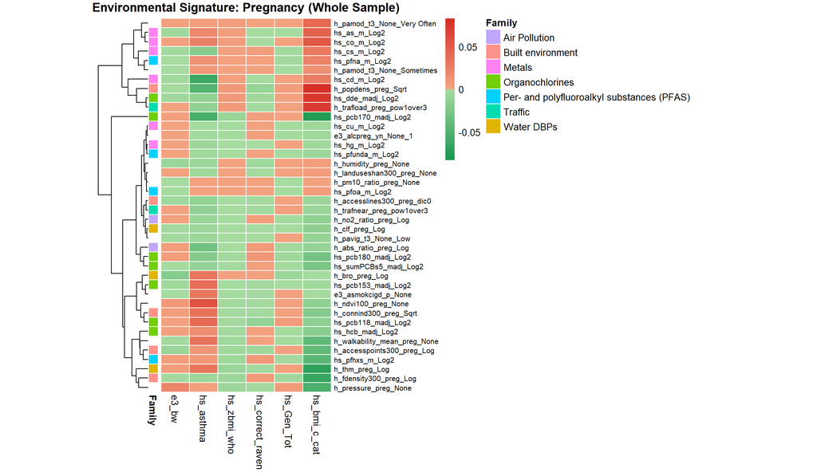

```r
# 9.3 Generate Final Heatmaps
# ------------------------------------------------------------------------------
# Note: We create a small wrapper list to reuse our 'plot_final_heatmap' function


# ------------------------------------------------------------------------------
# FUNCIÓN DE HEATMAP ACTUALIZADA (Para PDF y Whole Sample)
# ------------------------------------------------------------------------------
plot_final_heatmap <- function(model_obj, X_matrix, scenario_name) {

  # 1. Extraer Beta (Manejamos tanto estructura msrrr como msrrr.fit)
  if(!is.null(model_obj$fit)) {
    B_mat <- model_obj$fit$B
  } else {
    B_mat <- model_obj$B
  }

  rownames(B_mat) <- colnames(X_matrix)
  colnames(B_mat) <- colnames(Y_train)

  # 2. Filtrar filas activas
  active_rows <- rowSums(B_mat != 0) > 0
  coef_subset <- B_mat[active_rows, , drop = FALSE]

  if(nrow(coef_subset) == 0) {
    message(paste("    ! No hay coeficientes para el heatmap en:", scenario_name))
    return(NULL)
  }

  # 3. Anotaciones de fila
  clean_names <- gsub("_None|_Ter_2|_Ter_3", "", rownames(coef_subset))
  row_info <- vars_info %>%
    filter(variable_name %in% clean_names) %>%
    distinct(variable_name, .keep_all = TRUE)

  df_row_ann <- data.frame(
    Family = row_info$family[match(clean_names, row_info$variable_name)],
    row.names = rownames(coef_subset)
  )

  if(scenario_name == "Combined (Whole Sample)") {
    df_row_ann$Period <- ifelse(rownames(coef_subset) %in% colnames(X_preg_whole),
                                "Pregnancy", "Childhood")
  }

  # 4. CREAR EL GRÁFICO
  p <- pheatmap(
    coef_subset,
    main = paste("Environmental Signature:", scenario_name),
    color = custom_colors_pro,
    breaks = get_pro_breaks(coef_subset),
    annotation_row = df_row_ann,
    cluster_cols = FALSE,
    cluster_rows = TRUE,
    border_color = "white",
    fontsize_row = 8,
    cellwidth = 30,
    silent = TRUE # Evita que se dibuje antes de tiempo
  )

  # 5. IMPRESIÓN EXPLÍCITA (Crucial para el PDF)
  print(p)
}
# ------------------------------------------------------------------------------
# Bloque 9.3: Generar PDF Final
# ------------------------------------------------------------------------------
# Escenario A
grid.newpage() # Limpia el lienzo para la página 1
plot_final_heatmap(fit_preg_whole, X_preg_whole, "Pregnancy (Whole Sample)")
```

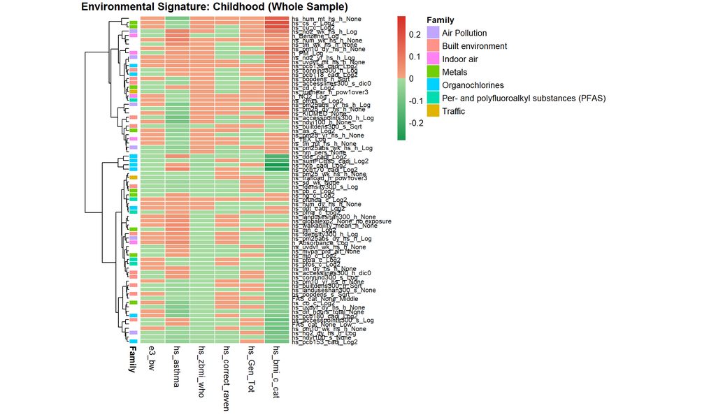

```r
# Escenario B
grid.newpage() # Salto a la página 2
plot_final_heatmap(fit_child_whole, X_child_whole, "Childhood (Whole Sample)")
```

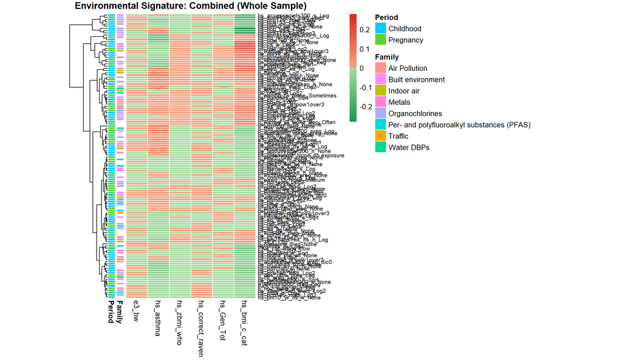

```r
# Escenario C
grid.newpage() # Salto a la página 3
X_comb_whole <- cbind(X_preg_whole, X_child_whole)
plot_final_heatmap(fit_comb_whole, X_comb_whole, "Combined (Whole Sample)")
```

# 11 11. STABILITY SELECTION: The “Stress Test” with Balanced Bootstrap

## 11.1 11.1 The Problem: Selection Uncertainty

A single model fit selects exposures based on that specific sample. Due to random sampling variation, different samples might select different variables.

**Question**: Are selected exposures **robust drivers** or **noise that happened to look significant**?

## 11.2 11.2 The Solution: Balanced Bootstrapping (500 Iterations)

### 11.2.1 Why “Balanced”?

**Standard Bootstrap**: Sampling WITH replacement - Some subjects appear 10 times, others 0 times - Creates “influence bias” where outliers over-dominate

**Balanced Bootstrap** (Our approach): - Create a “Grand Pool” with exactly 500 copies of EVERY participant - Shuffle and slice into 500 subsets - **Every participant contributes EXACTLY 500 times** - Eliminates influence bias

### 11.2.2 The post-bootstrap stability filtering system

Because standard parametric assumptions often fail in high-dimensional and non-normal environmental data, we extract complementary metrics from the bootstrap distribution to evaluate each exposure-outcome pair:

1. **Selection Probability (`sel_prob`):** proportion of bootstrap samples in which the exposure-outcome coefficient is selected, i.e., non-zero. This is the primary stability metric. The default filter used below is `sel_prob >= 0.90`, although this threshold can be relaxed (for example to 0.80 or 0.75) if no associations pass.
2. **Directional Consistency (`sign_consistency`):** among the bootstrap samples in which the coefficient is selected, the proportion that keep the same sign as the original whole-sample coefficient. This is used as an optional stricter filter, with default `sign_consistency >= 0.80`.
3. **Auxiliary bootstrap statistics (`pval_ratio`, `pval_corrected`, `th_pval`):** these are still computed for reference and sensitivity checks, but the stable heatmaps generated below are based on selection probability and, optionally, directional consistency.

The final block of this pipeline dynamically filters the global coefficient matrix using these stability metrics, masking associations that do not pass the selected criteria to zero, thereby generating the ultimate, validated **Stable Heatmap**.

```r
# ==============================================================================
# BLOCK 10: BOOTSTRAPPING WHOLE SAMPLE - PREGNANCY
# ==============================================================================
message(">>> [Block 10] Starting Bootstrap: Pregnancy Scenario...")

# 10.1 Data Preparation
# ------------------------------------------------------------------------------
X_boot <- X_preg_whole
Z_boot <- Z_whole
Y_boot <- Y_whole
n_boot <- 500

# 10.2 Generate Resampling Indices
# ------------------------------------------------------------------------------
boot_sampling <- generate_resampling_msrrr(
  blocks             = list(X_boot, Z_boot, Y_boot),
  n_boot             = n_boot,
  balanced           = TRUE,
  keep_all_variables = FALSE,
  verbose            = TRUE
)

# 10.3 Pre-processing: Filter Covariates (Z) for Variance Stability
# ------------------------------------------------------------------------------
sd_null <- boot_sampling$sd_null
if (!is.null(sd_null)) {
  message("    -> Removing covariates with zero variance in some partitions...")
  Z_boot <- Z_boot[, -which(colnames(Z_boot) %in% names(sd_null[[2]]))]
} else {
  message("    -> OK: No covariate filtering needed.")
}

# 10.4 Parallel Computing Setup (PSOCK)
# ------------------------------------------------------------------------------
require(doSNOW)
num_cores <- detectCores() - 1
cl        <- parallel::makeCluster(num_cores, type = "PSOCK")

registerDoParallel(cl)
registerDoSNOW(cl)

# Progress Bar Setup
pb       <- txtProgressBar(max = n_boot, style = 3)
```

```
  |                                                                              |                                                                      |   0%
```

```r
progress <- function(n) setTxtProgressBar(pb, n)
opts     <- list(progress = progress)

# 10.5 Core Bootstrap Loop (foreach)
# ------------------------------------------------------------------------------
message(paste("    -> Running", n_boot, "iterations on", num_cores, "cores..."))

boot_output <- foreach(
  i           = 1:n_boot,
  .combine    = "cbind",
  .packages   = c(
    "RMTL", "data.table", "rrpack", "MCMCpack", "GIGrvg", "utils", "MASS",
    "nortest", "MBSP", "foreach", "Matrix", "parallel", "glmnet", "spls",
    # "MXM", "dlnm",
    "splines", "mgcv", "doParallel", "ranger",
    "palmerpenguins", "tidyverse", "kableExtra", "haven", "corrplot", "pheatmap"
  ),
  .options.snow = opts
) %dopar% {

  # Core Worker Function
  unlist(msrrr_bootstrap_k(
    Y           = Y_boot,
    X           = X_boot,
    Z           = Z_boot,
    inds        = boot_sampling$full_idx[i],
    family      = outcome_families,
    familygroup = family_mapping,
    nrank       = results_whole_df$Opt_Rank[1], # Pregnancy Rank
    lambda      = results_whole_df$Opt_Lambda[1]      # Pregnancy Lambda
  ))
}
```

```
  |                                                                              |                                                                      |   1%  |                                                                              |=                                                           …
```

```r
stopCluster(cl)
close(pb)
```

```r
# 10.6 Advanced Statistical Extraction
# ------------------------------------------------------------------------------
message("    -> Calculating stability metrics...")

# Prepare grid for mapping results
grid_df       <- expand.grid(exposures = colnames(X_boot),
                             outcomes  = colnames(Y_boot),
                             bootstraps = 1:n_boot)
grid_df$value <- as.vector(boot_output)

# Matrix representation for matrixStats performance
val_matrix <- matrix(grid_df$value, ncol = n_boot)
count_pos  <- matrixStats::rowSums2(val_matrix > 0)
count_neg  <- matrixStats::rowSums2(val_matrix < 0)
z_counts   <- cbind(count_pos, count_neg)
n_selected <- count_pos + count_neg

# Build Results Dataframe
res_preg <- cbind(
  matrixStats::rowMeans2(val_matrix),                    # 1. Mean Beta
  matrixStats::rowSds(val_matrix),                       # 2. SD
  matrixStats::rowMins(z_counts) / matrixStats::rowMaxs(z_counts), # 3. pval_ratio

  # Corrected P-value (Empirical density crossing zero)
  pmin(2 * matrixStats::rowMins(cbind(
    matrixStats::rowMeans2(val_matrix <= 0),
    matrixStats::rowMeans2(val_matrix >= 0)
  )), 1),                                                # 4. pval_corrected

  matrixStats::rowQuantiles(val_matrix, probs = c(0.025, 0.975)), # 5. 95% CI
  matrixStats::rowMeans2(val_matrix != 0)                # 6. Selection Probability


)

colnames(res_preg) <- c("mean", "sd", "pval_ratio", "pval_corrected",
                        "lower_bound", "upper_bound", "sel_prob")

res_preg          <- data.frame(res_preg)
res_preg$exposure <- rep(colnames(X_boot), times = ncol(Y_boot))
res_preg$outcome  <- rep(colnames(Y_boot), each = ncol(X_boot))

# --- ADDITIONAL STATISTICS (Theoretical/Parametric) ---
#-----------Compute additional statistics using aggregated statistics
original_betas <- fit_preg_whole$B
colnames(original_betas) <- colnames(Y_boot)
rownames(original_betas) <- colnames(X_boot)
original_betas <- as.data.frame(original_betas)
original_betas$Predictor <- rownames(original_betas)
original_betas <- melt(original_betas, id.vars = "Predictor", variable.name = "Outcome", value.name = "Value")
original_betas$Predictor == res_preg$exposure
```

[output not shown]

```r
original_betas$Outcome == res_preg$outcome
```

[output not shown]

```r
tail <- qnorm(1 - .05 / 2)
res_preg$bootstrap_ratio <- original_betas$Value / res_preg$sd
res_preg$th_pval <- 2 * pnorm(abs(res_preg$bootstrap_ratio), lower.tail = FALSE)
res_preg$th_lower_bound <- original_betas$Value - res_preg$sd * tail
res_preg$th_upper_bound <- original_betas$Value + res_preg$sd * tail

# Directional consistency relative to the original whole-sample coefficient
# Among selected bootstrap coefficients, calculate the proportion that keep
# the same sign as the original whole-sample coefficient.
orig_sign <- sign(original_betas$Value)
n_same_sign_as_original <- matrixStats::rowSums2(
  (sign(val_matrix) == orig_sign) & (val_matrix != 0),
  na.rm = TRUE
)
res_preg$n_selected <- n_selected
res_preg$sign_consistency <- ifelse(
  n_selected > 0 & orig_sign != 0,
  n_same_sign_as_original / n_selected,
  NA_real_
)


# ==============================================================================
# BLOCK 10: BOOTSTRAPPING WHOLE SAMPLE - CHILDHOOD
# ==============================================================================
message(">>> [Block 10] Starting Bootstrap: Childhood Scenario...")

# 10.1 Data Preparation
# ------------------------------------------------------------------------------
X_boot <- X_child_whole
Z_boot <- Z_whole
Y_boot <- Y_whole
n_boot <- 500

# 10.2 Generate Resampling Indices
# ------------------------------------------------------------------------------
boot_sampling <- generate_resampling_msrrr(
  blocks             = list(X_boot, Z_boot, Y_boot),
  n_boot             = n_boot,
  balanced           = TRUE,
  keep_all_variables = FALSE,
  verbose            = TRUE
)

# 10.3 Pre-processing: Filter Covariates (Z) for Variance Stability
# ------------------------------------------------------------------------------
sd_null <- boot_sampling$sd_null
if (!is.null(sd_null)) {
  message("    -> Removing covariates with zero variance in some partitions...")
  Z_boot <- Z_boot[, -which(colnames(Z_boot) %in% names(sd_null[[2]]))]
} else {
  message("    -> OK: No covariate filtering needed.")
}

# 10.4 Parallel Computing Setup (PSOCK)
# ------------------------------------------------------------------------------
require(doSNOW)
num_cores <- detectCores() - 1
cl        <- parallel::makeCluster(num_cores, type = "PSOCK")

registerDoParallel(cl)
registerDoSNOW(cl)

# Progress Bar Setup
pb       <- txtProgressBar(max = n_boot, style = 3)
```

```
  |                                                                              |                                                                      |   0%
```

```r
progress <- function(n) setTxtProgressBar(pb, n)
opts     <- list(progress = progress)

# 10.5 Core Bootstrap Loop (foreach)
# ------------------------------------------------------------------------------
message(paste("    -> Running", n_boot, "iterations on", num_cores, "cores..."))

boot_output <- foreach(
  i           = 1:n_boot,
  .combine    = "cbind",
  .packages   = c(
    "RMTL", "data.table", "rrpack", "MCMCpack", "GIGrvg", "utils", "MASS",
    "nortest", "MBSP", "foreach", "Matrix", "parallel", "glmnet", "spls",
    # "MXM", "dlnm",
    "splines", "mgcv", "doParallel", "ranger",
    "palmerpenguins", "tidyverse", "kableExtra", "haven", "corrplot", "pheatmap"
  ),
  .options.snow = opts
) %dopar% {

  # Core Worker Function
  unlist(msrrr_bootstrap_k(
    Y           = Y_boot,
    X           = X_boot,
    Z           = Z_boot,
    inds        = boot_sampling$full_idx[i],
    family      = outcome_families,
    familygroup = family_mapping,
    nrank       = results_whole_df$Opt_Rank[2], # Childhood Rank
    lambda      = results_whole_df$Opt_Lambda[2]      # Childhood Lambda
  ))
}
```

```
  |                                                                              |                                                                      |   1%  |                                                                              |=                                                           …
```

```r
stopCluster(cl)
close(pb)
```

```r
# 10.6 Advanced Statistical Extraction
# ------------------------------------------------------------------------------
message("    -> Calculating stability metrics...")

# Prepare grid for mapping results
grid_df       <- expand.grid(exposures = colnames(X_boot),
                             outcomes  = colnames(Y_boot),
                             bootstraps = 1:n_boot)
grid_df$value <- as.vector(boot_output)

# Matrix representation for matrixStats performance
val_matrix <- matrix(grid_df$value, ncol = n_boot)
count_pos  <- matrixStats::rowSums2(val_matrix > 0)
count_neg  <- matrixStats::rowSums2(val_matrix < 0)
z_counts   <- cbind(count_pos, count_neg)
n_selected <- count_pos + count_neg

# Build Results Dataframe
res_child <- cbind(
  matrixStats::rowMeans2(val_matrix),                    # 1. Mean Beta
  matrixStats::rowSds(val_matrix),                       # 2. SD
  matrixStats::rowMins(z_counts) / matrixStats::rowMaxs(z_counts), # 3. pval_ratio

  # Corrected P-value (Empirical density crossing zero)
  pmin(2 * matrixStats::rowMins(cbind(
    matrixStats::rowMeans2(val_matrix <= 0),
    matrixStats::rowMeans2(val_matrix >= 0)
  )), 1),                                                # 4. pval_corrected

  matrixStats::rowQuantiles(val_matrix, probs = c(0.025, 0.975)), # 5. 95% CI
  matrixStats::rowMeans2(val_matrix != 0)                # 6. Selection Probability


)

colnames(res_child) <- c("mean", "sd", "pval_ratio", "pval_corrected",
                        "lower_bound", "upper_bound", "sel_prob")

res_child          <- data.frame(res_child)
res_child$exposure <- rep(colnames(X_boot), times = ncol(Y_boot))
res_child$outcome  <- rep(colnames(Y_boot), each = ncol(X_boot))

# --- ADDITIONAL STATISTICS (Theoretical/Parametric) ---
#-----------Compute additional statistics using aggregated statistics
original_betas <- fit_child_whole$B
colnames(original_betas) <- colnames(Y_boot)
rownames(original_betas) <- colnames(X_boot)
original_betas <- as.data.frame(original_betas)
original_betas$Predictor <- rownames(original_betas)
original_betas <- melt(original_betas, id.vars = "Predictor", variable.name = "Outcome", value.name = "Value")
original_betas$Predictor == res_child$exposure
```

[output not shown]

[output cut: 16 more lines]

```r
original_betas$Outcome == res_child$outcome
```

[output not shown]

[output cut: 16 more lines]

```r
tail <- qnorm(1 - .05 / 2)
res_child$bootstrap_ratio <- original_betas$Value / res_child$sd
res_child$th_pval <- 2 * pnorm(abs(res_child$bootstrap_ratio), lower.tail = FALSE)
res_child$th_lower_bound <- original_betas$Value - res_child$sd * tail
res_child$th_upper_bound <- original_betas$Value + res_child$sd * tail

# Directional consistency relative to the original whole-sample coefficient
# Among selected bootstrap coefficients, calculate the proportion that keep
# the same sign as the original whole-sample coefficient.
orig_sign <- sign(original_betas$Value)
n_same_sign_as_original <- matrixStats::rowSums2(
  (sign(val_matrix) == orig_sign) & (val_matrix != 0),
  na.rm = TRUE
)
res_child$n_selected <- n_selected
res_child$sign_consistency <- ifelse(
  n_selected > 0 & orig_sign != 0,
  n_same_sign_as_original / n_selected,
  NA_real_
)


# ==============================================================================
# BLOCK 10: BOOTSTRAPPING WHOLE SAMPLE - COMBINED
# ==============================================================================
message(">>> [Block 10] Starting Bootstrap: Combined Scenario...")

# 10.1 Data Preparation
# ------------------------------------------------------------------------------
X_boot <- X_comb_whole
Z_boot <- Z_whole
Y_boot <- Y_whole
n_boot <- 500

# 10.2 Generate Resampling Indices
# ------------------------------------------------------------------------------
boot_sampling <- generate_resampling_msrrr(
  blocks             = list(X_boot, Z_boot, Y_boot),
  n_boot             = n_boot,
  balanced           = TRUE,
  keep_all_variables = FALSE,
  verbose            = TRUE
)

# 10.3 Pre-processing: Filter Covariates (Z) for Variance Stability
# ------------------------------------------------------------------------------
sd_null <- boot_sampling$sd_null
if (!is.null(sd_null)) {
  message("    -> Removing covariates with zero variance in some partitions...")
  Z_boot <- Z_boot[, -which(colnames(Z_boot) %in% names(sd_null[[2]]))]
} else {
  message("    -> OK: No covariate filtering needed.")
}

# 10.4 Parallel Computing Setup (PSOCK)
# ------------------------------------------------------------------------------
require(doSNOW)
num_cores <- detectCores() - 1
cl        <- parallel::makeCluster(num_cores, type = "PSOCK")

registerDoParallel(cl)
registerDoSNOW(cl)

# Progress Bar Setup
pb       <- txtProgressBar(max = n_boot, style = 3)
```

```
  |                                                                              |                                                                      |   0%
```

```r
progress <- function(n) setTxtProgressBar(pb, n)
opts     <- list(progress = progress)

# 10.5 Core Bootstrap Loop (foreach)
# ------------------------------------------------------------------------------
message(paste("    -> Running", n_boot, "iterations on", num_cores, "cores..."))

boot_output <- foreach(
  i           = 1:n_boot,
  .combine    = "cbind",
  .packages   = c(
    "RMTL", "data.table", "rrpack", "MCMCpack", "GIGrvg", "utils", "MASS",
    "nortest", "MBSP", "foreach", "Matrix", "parallel", "glmnet", "spls",
    # "MXM", "dlnm",
    "splines", "mgcv", "doParallel", "ranger",
    "palmerpenguins", "tidyverse", "kableExtra", "haven", "corrplot", "pheatmap"
  ),
  .options.snow = opts
) %dopar% {

  # Core Worker Function
  unlist(msrrr_bootstrap_k(
    Y           = Y_boot,
    X           = X_boot,
    Z           = Z_boot,
    inds        = boot_sampling$full_idx[i],
    family      = outcome_families,
    familygroup = family_mapping,
    nrank       = results_whole_df$Opt_Rank[3], # Combined Rank
    lambda      = results_whole_df$Opt_Lambda[3]      # Combined Lambda
  ))
}
```

```
  |                                                                              |                                                                      |   1%  |                                                                              |=                                                           …
```

```r
stopCluster(cl)
close(pb)
```

```r
# 10.6 Advanced Statistical Extraction
# ------------------------------------------------------------------------------
message("    -> Calculating stability metrics...")

# Prepare grid for mapping results
grid_df       <- expand.grid(exposures = colnames(X_boot),
                             outcomes  = colnames(Y_boot),
                             bootstraps = 1:n_boot)
grid_df$value <- as.vector(boot_output)

# Matrix representation for matrixStats performance
val_matrix <- matrix(grid_df$value, ncol = n_boot)
count_pos  <- matrixStats::rowSums2(val_matrix > 0)
count_neg  <- matrixStats::rowSums2(val_matrix < 0)
z_counts   <- cbind(count_pos, count_neg)
n_selected <- count_pos + count_neg

# Build Results Dataframe
res_comb_ <- cbind(
  matrixStats::rowMeans2(val_matrix),                    # 1. Mean Beta
  matrixStats::rowSds(val_matrix),                       # 2. SD
  matrixStats::rowMins(z_counts) / matrixStats::rowMaxs(z_counts), # 3. pval_ratio

  # Corrected P-value (Empirical density crossing zero)
  pmin(2 * matrixStats::rowMins(cbind(
    matrixStats::rowMeans2(val_matrix <= 0),
    matrixStats::rowMeans2(val_matrix >= 0)
  )), 1),                                                # 4. pval_corrected

  matrixStats::rowQuantiles(val_matrix, probs = c(0.025, 0.975)), # 5. 95% CI
  matrixStats::rowMeans2(val_matrix != 0)                # 6. Selection Probability


)

colnames(res_comb_) <- c("mean", "sd", "pval_ratio", "pval_corrected",
                         "lower_bound", "upper_bound", "sel_prob")

res_comb_          <- data.frame(res_comb_)
res_comb_$exposure <- rep(colnames(X_boot), times = ncol(Y_boot))
res_comb_$outcome  <- rep(colnames(Y_boot), each = ncol(X_boot))

# --- ADDITIONAL STATISTICS (Theoretical/Parametric) ---
#-----------Compute additional statistics using aggregated statistics
original_betas <- fit_comb_whole$B
colnames(original_betas) <- colnames(Y_boot)
rownames(original_betas) <- colnames(X_boot)
original_betas <- as.data.frame(original_betas)
original_betas$Predictor <- rownames(original_betas)
original_betas <- melt(original_betas, id.vars = "Predictor", variable.name = "Outcome", value.name = "Value")
original_betas$Predictor == res_comb_$exposure
```

[output not shown]

[output cut: 37 more lines]

```r
original_betas$Outcome == res_comb_$outcome
```

[output not shown]

[output cut: 37 more lines]

```r
tail <- qnorm(1 - .05 / 2)
res_comb_$bootstrap_ratio <- original_betas$Value / res_comb_$sd
res_comb_$th_pval <- 2 * pnorm(abs(res_comb_$bootstrap_ratio), lower.tail = FALSE)
res_comb_$th_lower_bound <- original_betas$Value - res_comb_$sd * tail
res_comb_$th_upper_bound <- original_betas$Value + res_comb_$sd * tail

# Directional consistency relative to the original whole-sample coefficient
# Among selected bootstrap coefficients, calculate the proportion that keep
# the same sign as the original whole-sample coefficient.
orig_sign <- sign(original_betas$Value)
n_same_sign_as_original <- matrixStats::rowSums2(
  (sign(val_matrix) == orig_sign) & (val_matrix != 0),
  na.rm = TRUE
)
res_comb_$n_selected <- n_selected
res_comb_$sign_consistency <- ifelse(
  n_selected > 0 & orig_sign != 0,
  n_same_sign_as_original / n_selected,
  NA_real_
)
```

# 12 12. THE STABLE HEATMAP: Filtering by Bootstrap Stability

## 12.1 12.1 Interpretation of the Stable Signature

This is a “cleaned” signature. The primary filter is based on **selection probability** (`sel_prob >= 0.90`). A stricter version additionally requires **directional consistency** (`sign_consistency >= 0.80`) among selected bootstrap coefficients.

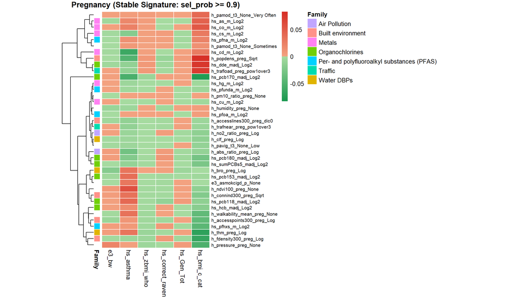

```r
# ==============================================================================
# BLOCK 12: UNIVERSAL STABLE HEATMAP GENERATOR
# ==============================================================================
# DESCRIPTION: Generates cleaned heatmaps by masking associations that do not
#              pass the selected post-bootstrap stability criteria.
# ==============================================================================

# ------------------------------------------------------------------------------
# 12.0 User-defined post-bootstrap filtering thresholds
# ------------------------------------------------------------------------------
# Two filters are generated:
#
# 1) Selection-stability filter:
#    sel_prob >= sel_prob_threshold
#
# 2) Stricter stability filter:
#    sel_prob >= sel_prob_threshold and
#    sign_consistency >= sign_consistency_threshold
#
# The default values below are practical starting points, not universal rules.
# Lower thresholds may retain more associations; higher thresholds will give a
# more conservative stable signature.

sel_prob_threshold <- 0.90
sign_consistency_threshold <- 0.80

# 12.1 Define the Universal Plotting Function
# ------------------------------------------------------------------------------
plot_stable_signature <- function(fit_whole, boot_res, X_mat,
                                  scenario_name,
                                  sel_prob_threshold = 0.90,
                                  sign_consistency_threshold = 0.80,
                                  require_sign_consistency = FALSE) {

  filter_label <- if(require_sign_consistency) {
    paste0("sel_prob >= ", sel_prob_threshold,
           " & sign_consistency >= ", sign_consistency_threshold)
  } else {
    paste0("sel_prob >= ", sel_prob_threshold)
  }

  message(paste0(">>> Generating Stable Heatmap for: ", scenario_name))
  message(paste0("    -> Filter: ", filter_label))

  # A. EXTRACT ORIGINAL BETAS
  # ----------------------------------------------------------------------------
  # Get the B matrix from the whole sample fit
  B_orig <- fit_whole$B
  rownames(B_orig) <- colnames(X_mat)
  colnames(B_orig) <- colnames(Y_whole)

  # B. PREPARE THE SELECTION-PROBABILITY MASK
  # ----------------------------------------------------------------------------
  sel_prob_mask <- boot_res %>%
    select(exposure, outcome, sel_prob) %>%
    tidyr::pivot_wider(names_from = outcome, values_from = sel_prob) %>%
    tibble::column_to_rownames("exposure")

  # Align rows and columns with B matrix
  sel_prob_mask <- sel_prob_mask[rownames(B_orig), colnames(B_orig)]
  stability_mask <- as.matrix(sel_prob_mask) >= sel_prob_threshold

  # C. ADD DIRECTIONAL CONSISTENCY MASK IF REQUESTED
  # ----------------------------------------------------------------------------
  if(require_sign_consistency) {
    sign_consistency_mask <- boot_res %>%
      select(exposure, outcome, sign_consistency) %>%
      tidyr::pivot_wider(names_from = outcome, values_from = sign_consistency) %>%
      tibble::column_to_rownames("exposure")

    # Align rows and columns with B matrix
    sign_consistency_mask <- sign_consistency_mask[rownames(B_orig), colnames(B_orig)]
    stability_mask <- stability_mask &
      (as.matrix(sign_consistency_mask) >= sign_consistency_threshold)
  }

  stability_mask[is.na(stability_mask)] <- FALSE

  # D. APPLY THE FILTER (MASKING)
  # ----------------------------------------------------------------------------
  B_stable <- B_orig
  B_stable[!stability_mask] <- 0

  # E. POST-FILTER CLEANUP
  # ----------------------------------------------------------------------------
  # Remove rows that are entirely zero after masking (cleaner visualization)
  active_rows <- rowSums(B_stable != 0) > 0
  if(sum(active_rows) == 0) {
    message("    ! WARNING: No associations survived the stability filter.")
    return(NULL)
  }
  coef_subset <- B_stable[active_rows, , drop = FALSE]

  # F. ROW ANNOTATIONS (Families)
  # ----------------------------------------------------------------------------
  clean_names <- gsub("_None|_Ter_2|_Ter_3", "", rownames(coef_subset))
  row_info <- vars_info %>%
    filter(variable_name %in% clean_names) %>%
    distinct(variable_name, .keep_all = TRUE)

  df_row_ann <- data.frame(
    Family = row_info$family[match(clean_names, row_info$variable_name)],
    row.names = rownames(coef_subset)
  )

  # G. RENDER PHEATMAP
  # ----------------------------------------------------------------------------
  p <- pheatmap(
    coef_subset,
    main              = paste0(scenario_name, " (Stable Signature: ", filter_label, ")"),
    color             = custom_colors_pro,          # Defined in Block 8
    breaks            = get_pro_breaks(coef_subset),# Defined in Block 8
    annotation_row    = df_row_ann,
    cluster_cols      = FALSE,
    cluster_rows      = TRUE,
    border_color      = "white",
    fontsize_row      = 8,
    cellwidth         = 30,
    silent            = TRUE
  )

  print(p)
}

# 12.2 Generate stable signatures using the two stability filters
# ------------------------------------------------------------------------------

# Pregnancy, selection probability only
grid.newpage()
plot_stable_signature(fit_preg_whole, res_preg, X_preg_whole,
                      "Pregnancy",
                      sel_prob_threshold = sel_prob_threshold,
                      sign_consistency_threshold = sign_consistency_threshold,
                      require_sign_consistency = FALSE)
```

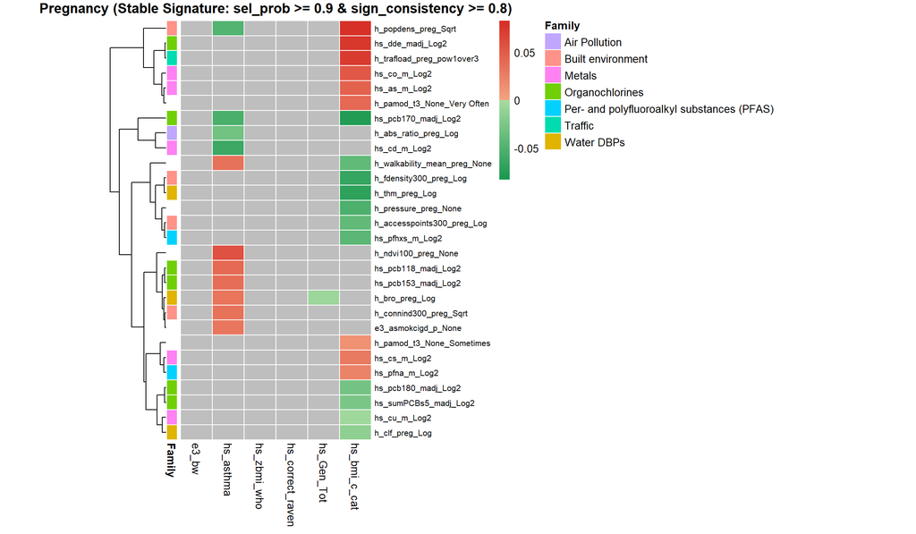

```r
# Pregnancy, selection probability + directional consistency
grid.newpage()
plot_stable_signature(fit_preg_whole, res_preg, X_preg_whole,
                      "Pregnancy",
                      sel_prob_threshold = sel_prob_threshold,
                      sign_consistency_threshold = sign_consistency_threshold,
                      require_sign_consistency = TRUE)
```

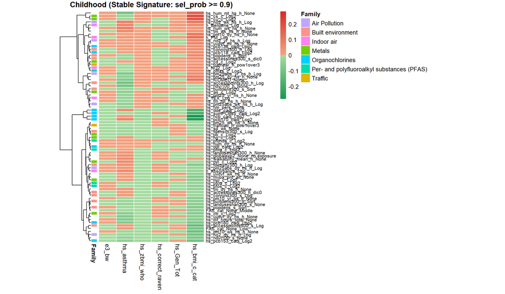

```r
# Childhood, selection probability only
grid.newpage()
plot_stable_signature(fit_child_whole, res_child, X_child_whole,
                      "Childhood",
                      sel_prob_threshold = sel_prob_threshold,
                      sign_consistency_threshold = sign_consistency_threshold,
                      require_sign_consistency = FALSE)
```

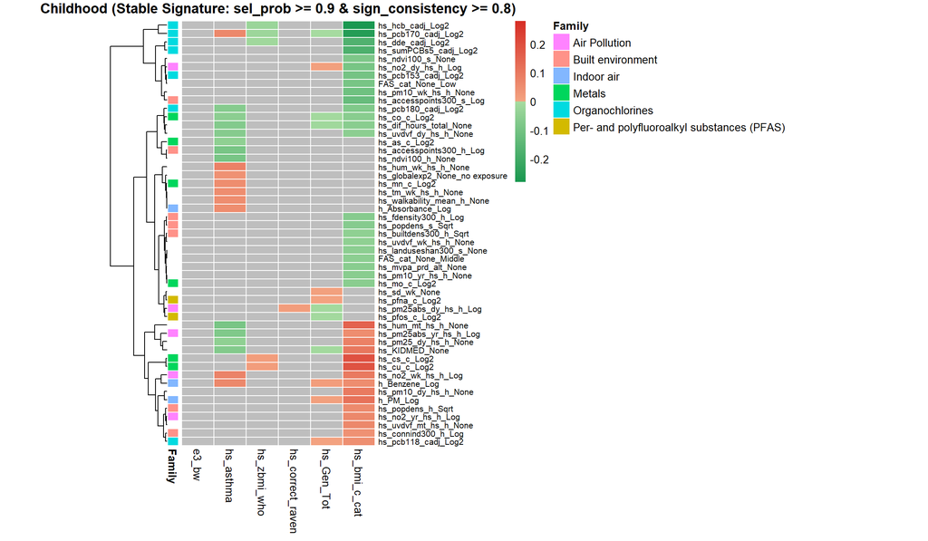

```r
# Childhood, selection probability + directional consistency
grid.newpage()
plot_stable_signature(fit_child_whole, res_child, X_child_whole,
                      "Childhood",
                      sel_prob_threshold = sel_prob_threshold,
                      sign_consistency_threshold = sign_consistency_threshold,
                      require_sign_consistency = TRUE)
```

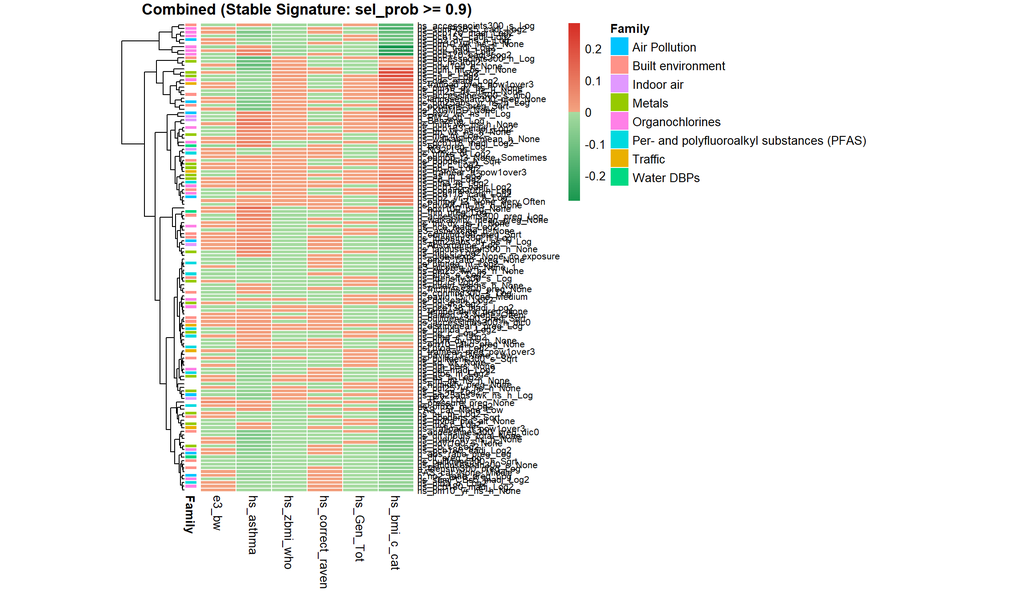

```r
# Combined, selection probability only
grid.newpage()
X_comb_whole <- cbind(X_preg_whole, X_child_whole)
plot_stable_signature(fit_comb_whole, res_comb_, X_comb_whole,
                      "Combined",
                      sel_prob_threshold = sel_prob_threshold,
                      sign_consistency_threshold = sign_consistency_threshold,
                      require_sign_consistency = FALSE)
```

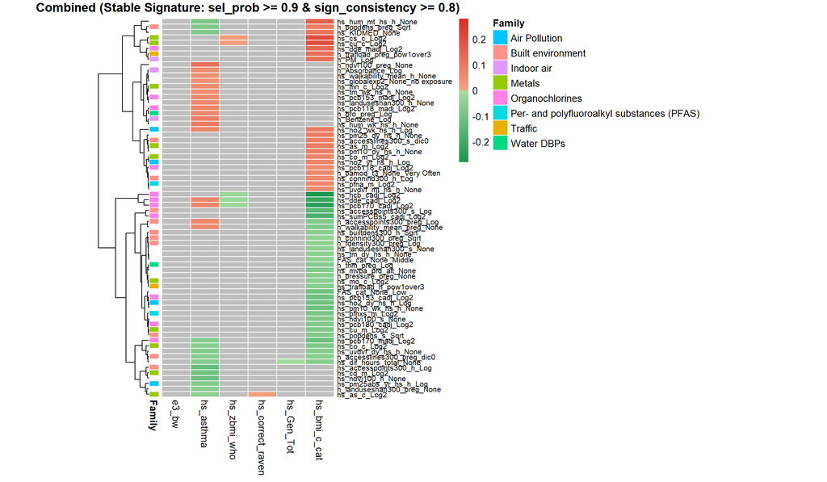

```r
# Combined, selection probability + directional consistency
grid.newpage()
plot_stable_signature(fit_comb_whole, res_comb_, X_comb_whole,
                      "Combined",
                      sel_prob_threshold = sel_prob_threshold,
                      sign_consistency_threshold = sign_consistency_threshold,
                      require_sign_consistency = TRUE)
```

# 13 13. INTERPRETATION EXAMPLES: What a Stable Signature Means

## 13.2 13.2 White Cell Example (Multiple Interpretations)

# 14 14. METHODOLOGICAL SUMMARY: From P-Hacking to P-Validating

## 14.1 14.1 The Evolution

| Approach | Method | Problem | Solution |
| --- | --- | --- | --- |
| **Classical Regression** | OLS (X^T X)^-1 X^T Y | P >> N → singular matrix | ✗ Fails |
| **P-Hacking** | Univariate tests + FDR | Multiple testing → false positives | Reduces but doesn’t eliminate |
| **LASSO** | Single-run regularization | Selection uncertainty in noisy data | Unstable selections |
| **msRRR + Stability Selection** | 500 balanced bootstraps + selection probability/directional consistency | ✓ Validates robustness | P-VALIDATING |

**Key Difference**: We shift from “Is this p < 0.05?” to “How consistently is this selected across data perturbations?”

# 15 15. COMPUTATIONAL REQUIREMENTS & Scalability

# 16 16. FINAL RECOMMENDATIONS

### 16.0.1 For Publication:

1. **Report the selection probability threshold and any directional consistency filter used**
2. **Document the rank and lambda selection**—enables replication
3. **Show the bootstrap distribution**—demonstrates stability
4. **Include missing data strategy**—transparency

### 16.0.2 For Future Analyses:

1. **Sensitivity analyses**: Try different `sel_prob` thresholds (e.g., 0.90, 0.80, 0.75) and optional directional consistency thresholds
2. **Stratified models**: By sex, age groups
3. **Pleiotropy analysis**: Which exposures affect multiple outcomes?

# 17 APPENDIX: Quick Reference

**Three-Stage Protocol:**

```
Stage 1: Stratified 80/20 Split (prevent rare disease imbalance)
         ↓
Stage 2: 5-Fold CV on training (optimize rank & lambda)
         ↓
Stage 3: Whole sample refit + 500 bootstrap (maximize power + validate)
```

**Post-bootstrap Stability Filters:**

```
Primary filter:         sel_prob >= 0.90
Optional stricter filter: sign_consistency >= 0.80 among selected bootstraps

Auxiliary metrics such as pval_ratio, pval_corrected, and th_pval are still computed
for reference and sensitivity checks, but the stable heatmaps are generated from
selection probability and optional directional consistency.
```

**Author**: Augusto Anguita-Ruiz  
**Date**: 2026  
**Framework**: msRRR (Mixed-Response Sparse Reduced-Rank Regression)  
**Tutorial Purpose**: Educational & replication